# 这

Back to the balloon. Step 5. Refer to picture from Step 4. Think about problem again. Remember fluid mechanics study session with Mary et al. and Bernoulli looking over the bridge on the Arno at the two rocks. If the pressure in the tank is not a whole lot higher than atmospheric pressure, and the air is therefore not compressible, I can call it incompressible flow and use Bernoulli's equation. That will tell me how fast the air will flow from the tank into the balloon, depending on how much pressure there is in the tank compared to how much is in the balloon.

我还可以说，进入气球的所有东西都会导致气球变大。这是另一个方程，称为质量连续性方程。

I can also say that everything that goes into the balloon results in enlargement of the balloon. That's another equation, called the continuity of mass equation.

最后，我可以平衡气球表面上的力——气球的拉伸必须通过气球内部和外部的气压来平衡。这给了我三个方程和五个未知数。

And finally, I can balance the forces on the skin of the balloon-the stretchiness of the balloon has to be balanced by the air pressure inside and outside the balloon. That gives me three equations and five unknowns.

现在我要做的就是显示 x 如何随时间变化，这样我就可以绘制气球的位置，格林会认为我是英雄。

Now all I have to do is show how x varies with time, so I can graph the position of the balloon and Greene will think I'm a hero.

第 6 步：清理霍普金斯大学二年级的微分方程书本。微分方程处理随时间移动的事物，例如发动机的活塞、地球、月球或被吹胀的气球的表皮。

Step 6. Dust off differential equations book from sophomore year at Hopkins. A differential equation deals with things that move in time, like the piston of an engine, the earth, and the moonor the skin of a balloon being blown up.

微分方程书中的所有内容都涉及“线性”微分方程。这意味着第二项，即 x 点平方项，意味着我无法使用该书中的任何方法来解决这个问题。我将速度乘以速度，这使它成为“非线性”。

Everything in the differential equations book deals with "linear" differential equations. That means that the second term, the x-dot-squared term, means I can't solve this using any methods in that book. I'm multiplying the velocity by the velocity, and that makes it "nonlinear."

第7步：平底船。当研究所或问题集将你逼入绝境时，你在麻省理工学院就会这么做。

Step 7: Punt. This is what you do at MIT when the institute or the problem set has painted you into a corner.

3月2日

March 2

格林快速浏览了我的蒸汽系统解决方案，用他的十字笔检查了步骤。然后他让我到黑板前展示我对气球问题的解决方案。

Greene looked quickly through my steam system solution, checking off the steps with his Cross pen. Then he asked me to go to the blackboard to present my solution to the balloon problem.

“现在这是一个好主意，”他谈到我让气球只向一个方向膨胀时说道。“你知道，在我担任经理的这些年里，我发现有些人很有创造力，可以发明东西，有些人可以分析有创造力的人发明的东西。没有多少人能同时做到这两点，但这个解决方案让我知道你可能是其中之一。”

"Now that is a good idea," he said of my making the balloon expand in only one direction. "You know, in my years as a manager, I've found that there are people who are creative and can invent things and then there are people who can analyze things that the creative people have invented. Not many people can do both, but this solution shows me you might be one of them."

克维尔市。这家伙肯定会给我一个A。毕竟他们不能把我踢出去。

Kvel city. This guy's bound to give me an A. They won't be able to kick me out, after all.

我为他完成了这些步骤，并向他展示了我的一组不可解的方程。“这就是我的答案，”我说。“不幸的是，我不知道如何解决这个问题，以便能够将气球蒙皮的位置随时间的变化绘制出来。我想你可能会有一些建议。”

I went through the steps for him and showed him my insoluble set of equations. "This is my answer," I said. "Unfortunately, I don't know how to solve it, to be able to graph the position of the skin of the balloon as a function of time. I thought you might have some suggestions."

“好吧，如果你把这个问题带到联合碳化物公司给我，我会让应用数学部门的负责人来这里，他的一个人会在计算机上解决这个问题，”他说。“但你至少想知道足够的知识，以便与应用数学类型的人进行有知识的交谈，并防止他们在项目上花费太多时间。让我们沿着大厅到苹果公司，我将向你展示如何启动它。”

"Well, if you brought that problem to me at Union Carbide, I'd get the head of the applied mathematics department in here and one of his people would solve it on the computer," he said. "But you want to know at least enough to talk knowledgeably with the applied math types and prevent them from billing too many hours to the project. Let's go down the hall to the Apple and I'll show you how to boot it up."

电脑室是一间位于角落的办公室，大小相当于一个大壁橱，墙壁上都有窗户，还有一张桌子和苹果电脑。窗户望向七层楼的庭院。由于房间在二楼，所以从来没有阳光直射，但柔和的漫射光和窗外的树木让我感觉自己身处回廊的回廊中。

The computer room was a corner office the size of a large closet, with windows on both walls and a desk and the Apple. The windows looked out onto a seven-story courtyard; since the room was on the second floor it never received direct sunlight, but the soft diffuse light and the tree just outside the window made me feel I was in a cloister's cloister.

格林将一张软盘放入机器中，然后打开电源开关。我猜想这就是他所说的“启动它”的意思。

Greene put a diskette into the machine and turned on the on switch. I presumed that's what he meant by "booting it up."

“我将编写一个三行程序，为您添加两个数字，以向您展示如何开始，”他说。

"I'll just write a three-line program that will add two numbers for you to show you how to get started," he said.

他的手指在键盘上模糊不清，就像音乐会钢琴家的手指一样。与语音或手写不同，它们对信息传输的速度有天然的速度限制，而计算机几乎可以像他想象的那样快地接收信息。他在高中的盲打课上一定表现得很好。

His fingers blurred around the keyboard, like a concert pianist's. Unlike speech or writing by hand, which have natural speed limits on how fast information can be transfered, the computer could receive information almost as quickly as he thought. He must have done well in touch typing class in high school.

当他完成后，屏幕显示“输入A”，我输入3。“输入B”，它说，我输入5。“A + B = 8”，它说。

When he was done, the screen said "Input A," and I typed 3. "Input B," it said, and I typed 5. "A + B = 8," it said.

“你以前编程过，不是吗？” 他说。

"You've programmed before, haven't you?" he said.

“嗯，在大学的时候就知道了一点，但那总是在带有黄色纸张的电传终端上，该终端连接到大厅空调房中的一台大计算机。这看起来有点不同。”

"Well, just a little in college, but that was always on a teletype terminal with the yellow paper that was connected to a big computer in an air-conditioned room down the hall. This looks a little different."

“原则上是一样的，”他说。“这里的抽屉里有一本编程手册，所以如果你需要帮助，你可以参考它。我希望你在下次会议上做的是建立你向我展示的方程式，这样你就可以逐步完成一些事情增加时间，看看当模型中的弹簧拉伸和气球中的压力升高时，气球的表面会发生什么变化。尝试组织方程，以便信息将从一个方程流到下一个方程，以便在每一步在程序中，计算机拥有继续下一步所需的所有数据。哦，并阅读编程指南中的“子例程”。您可以使用它们将一个大而复杂的问题分解为几个较小的问题，简单的问题。这将使调试变得更加容易。现在，让我们回到我的办公室，回顾一下你提出的熵的例子。”

"It's the same in principle," he said. "There's a programming manual in the drawer here, so you can refer to that if you need help. What I want you to do for our next meeting is to set up the equations you showed me in such a way that you can step through little increments of time and see what happens to the skin of the balloon as the spring in your model stretches and the pressure in your balloon rises. Try to organize the equations so the information will flow from one equation to the next, so that at each step in the program, the computer has all the data it needs to go on to the next step. Oh, and read up on'subroutines' in the programming guide. You can use them to break up a big, complex problem into several smaller, simple problems. It'll make debugging much easier. For now, let's go back to my office and go over the examples of entropy you've come up with."

垃圾填埋场、暴饮暴食、吸烟、吸毒——在过去的两周里，现代生活的所有弊病都浮现在脑海中，但我知道他想要更具体的东西。

Landfills, overeating, smoking, drug addiction-all the ills of modern life had come to mind during the past two weeks, but I knew he'd want something more specific.

“嗯，有一天，我在马萨诸塞州大街的人行横道上，看到有人试图平行停车在一个对汽车来说短了大约 6 英寸的空间中。对于街区的长度来说，有 2 或 3 英尺其他汽车之间的距离有时长达 4 英尺。因此，如果将这些小空间加起来，您可能可以轻松地在街区中容纳三到四辆汽车。但是这些小空间本身是没有用的.这是我能想到的最好的办法了。”

"Well, the other day I was at the crosswalk at Mass. Ave. and I saw somebody trying to parallel park in a space that was about 6 inches too short for the car. For the length of the block there were 2 or 3 feet between the other cars, sometimes as much as 4 feet. So if you added up the little pieces of space you'd probably be able to fit three or four more cars into the block comfortably. But the little pieces of space by themselves were useless. That's the best I could come up with."

“这是一件好事，”他说。“你可以打个比方，空间相当于能量，空间的短小相当于熵。空间越长，代表的系统越有序，就越有用。这样很好，我就这样。我认为你正在取得进步。”

"That's a good one," he said. "You could make the analogy that space is the equivalent of energy, and the shortness of the space is the equivalent of entropy. The longer the space is, the more ordered a system it represents and the more useful it is. That's good. I like that. I think you're making progress."

# 章节

# C H A P T E R

# 9

# 9

# 春天

# Spring

3月15日

March 15

选战风云。零度以上的第一天，是时候清理掉精神上的蜘蛛网了。是时候去骑自行车了。我的逃生路线是穿过贝尔蒙特的特拉佩洛路。

The Ides of March. The first day above freezing, and time to blast the mental cobwebs out. Time to go on a bicycle ride. My escape route was out Trapelo Road through Belmont.

压力依然存在，但学期只有两场考试，放松的时间更多了。爬上第一个主要山坡贝尔蒙特山时，我记得我的旧自行车教练告诉我要坐在马鞍上并拉动上冲程。他说这样可以让我腿前面的肌肉放松，让用过的血液流出，新的血液流入。如果我总是用力推我的腿前面，紧张感就会增强，我的腿会感觉很累。我就会被从队伍中剔除。

The pressure was still constant, but with only two exams scheduled for the term, there was more relaxing time. Up the first major hill, Belmont Hill, I remembered my old cycling coach's telling me to sit back in the saddle and pull on the upstroke. He said that would allow the muscles in the front of my legs to relax and let the used blood flow out and the new blood flow in. If I always pushed on the front of my legs the tension would build up and my legs would feel tired and I'd be dropped from the pack.

这有点像海伍德对内燃机的描述。燃料进入气缸，燃烧，然后排出并排出。如果将废气留在气缸中，就没有空间容纳新鲜的、未燃烧的燃料和空气，你的汽车就会熄火。

It was sort of like Heywood's description of an internal combustion engine. Fuel goes into the cylinder, gets burned, then pushed out and exhausted. If you kept the exhaust in the cylinder, there wouldn't be room for the fresh, unburned fuel and air, and your car would stall.

在 128 号公路立交桥处，我上下看了看八车道的高速公路。两侧是连绵不断的二层楼房。旁边的牌子上写着“128号公路：美国科技高速公路”。我继续前行，经过霍尼韦尔光电部门、雷神公司贝德福德导弹系统部门、数字公司、EG&G。

At the Route 128 overpass, I looked both ways up and down the eight-lane highway. On both sides were continuous lines of two-story buildings. The sign on the side said, "Route 128: Amer ica's Technology Highway." I rode on, past Honeywell's ElectroOptic Division, past Raytheon's Bedford Missile Systems Division, past Digital, past E.G.& G.

所有这些地方要么是由麻省理工学院的毕业生创建的，要么是由麻省理工学院的毕业生组成的。哈维家族在纽约拥有大部分权力，但最有权势的技术人员在 7 号楼二十英里范围内生活和工作。我想知道在一栋只有小隔间和很少窗户的低层建筑中工作会是什么样子。

All these places were either founded by or heavily populated by MIT grads. The Harveys have most of their power in New York, but the most powerful Techies live and work within twenty miles of Building 7. I wondered what it would be like to work in a lowrise building with cubicles and very few windows.

穿过康科德中心并经过肯·奥尔森的房子。Ken Olsen 于 50 年代从麻省理工学院毕业，随后在旋风计划中与 Jay Forrester 教授一起研究计算机内存技术，并从那里分拆了一家公司——数字设备公司。肯的身价有十亿二十亿美元，但仍然住在简陋的家里。

On through Concord Center and past Ken Olsen's house. Ken Olsen graduated from MIT in '50, went on to work with Professor Jay Forrester on computer memory technology in Project Whirlwind, and from there spun off a company-Digital Equipment Corporation. Ken is worth a billion or two and still lives in a modest home.

再往前走，我看到了吉夫托普洛斯的勤劳成果。好吧，不是整个水果，因为车道太长，你无法从街上看到整个房子。隔壁是热电公司另一位创始人乔治·哈索普洛斯 (George Hatsopoulos) 的房子。乔治表明，你不必成为麻省理工学院的教授才能赚到一百万美元。就他而言，一名博士学位。机械工程专业知识和如何测量汽车尾气中氮氧化物浓度的好主意就足够了。

Farther on, I saw the fruit of Gyftopoulos's industry. Well, not the whole fruit, because you can't see the whole house from the street because the driveway's so long. Next door was the house of the other Thermo Electron founder, George Hatsopoulos. George showed that you don't have to be a professor at MIT to make a million bucks. In his case, a Ph.D. in mechanical engineering and a good idea for how to measure the concentration of nitrogen oxide in automobile exhaust were sufficient.

回到镇上，Thermo Electron 距离他们家不到五分钟车程。也许，如果我努力的话，我可以效仿他们所有人。

Back toward town Thermo Electron was less than a fiveminute drive from their houses. Maybe, if I worked hard, I could emulate all of them.

旅途感觉很好，洗完澡后，就到了苹果时间。格林给了我一把电脑房钥匙和一张软盘。

The ride felt good, and after my shower, it was Apple time. Greene had given me a key to the computer room and a floppy disk.

当时是两点钟，阳光明媚，如果我有勇气的话，我会很高兴继续骑自行车去康科德、卡莱尔、阿克顿或哈佛，但这不是我在剑桥的原因。

It was two o'clock, and sunny, and if I'd had my druthers I would have happily continued cycling on to Concord or Carlisle or Acton or Harvard, but that's not why I was in Cambridge.

回廊朝内，与街道隔绝，窗外有棵树，漫射的阳光照亮了粉红色石灰岩墙壁的上部，是一个宁静的避难所。这里只是我的想法，以及沃兹尼亚克和乔布斯这两个没有上过大学的人写的手册的智慧。

The cloister, facing inward, shielded from the street, with the tree just outside the window and the diffuse sunlight brightening the upper part of the pink limestone walls, was a peaceful sanctuary. Here it was just my thoughts, and the wit of the manual written by two guys who hadn't gone to college, Wozniak and Jobs.

好吧，苹果。我是用户。保持友好。

Okay Apple. I'm a user. Be friendly.

苹果以身作则。该语言是 BASIC，大多数人学习编程所使用的语言。在 BASIC 中，遵循示例程序的逻辑相当容易。我输入了示例程序，它们就工作了。这开始为我建立起因果关系；如果你输入正确的内容，并且没有放错括号，也没有拼写任何内容，并且绝对、完美、一致地正确执行，那么它就有效。

Apple taught by example. The language was BASIC, the language in which most people learn to program. In BASIC, it's fairly easy to follow the logic of the sample programs. I typed in the sample programs, and they worked. This began to establish a cause-and-effect relationship for me; if you type in the right thing and don't misplace parentheses and don't misspell anything and do it absolutely, perfectly, uniformly right, it works.

到了六点钟，我就完成了手册。这有点像听保罗·戴斯蒙德的唱片，试图挑选出即兴的即兴重复段，然后用我的单簧管随机演奏它们。我会一次拿起一个乐句，一旦我知道保罗·德斯蒙德在做什么，他在用什么和弦工作，他在修饰什么音阶，我就可以自己尝试，也许稍微改变一下顺序，尝试不同的音符排列。在我意识到之前我已经是一名程序员了。您模仿这些图案，并意外地发现新的组合并发展自己的风格。时间消失了，我迷失在其中，这几乎变得有趣，而不是工作。

By six o'clock I'd finished the manual. It was sort of like listening to a Paul Desmond record and trying to pick out the improvisational riffs and play them by ear on my clarinet. I'd pick it up a phrase at a time, and once I knew what Paul Desmond was doing, what chords he was working from, what scales he was embellishing, I could experiment on my own, maybe change the order a little bit, try different permutations of the notes. Before I knew it I was a programmer. You imitate the patterns, and by accident you discover new combinations and develop your own style. The time disappeared and I became lost in it and it became almost fun, not work.

日落后，办公室的灯光让窗户变成了镜子，我看到自己坐在电脑旁边，想象着《新闻周刊》上“麻省理工学院的怀特”的照片，这位才华横溢的年轻工程学教授，他的研究正在解决世界能源和环境问题。我会穿着 V 领套头衫，向后靠在办公椅上，双手抱在脑后，肘部向外。背景里的书柜已经满了。

After sunset the office light made the window a mirror, and I saw myself beside the computer and imagined the Newsweek picture of "MIT's White," the brilliant young engineering professor whose research is solving the world's energy and environmental problems. I'd wear a V-necked pullover, lean back in the desk chair, and have my hands clasped behind my head and elbows out. The bookcases in the background would be full.

回到气球。是时候参考方程和绘图了。格林曾说过，我需要考虑我编写的任何算法（解决方案方法）中的信息流。这意味着我需要将三个方程按顺序排列，以便一个计算的结果将输入到下一个计算的未知侧，该答案将输入到下一个计算的未知侧，依此类推。这就是我将如何穿越时空并吹爆我的气球。

Back to the balloon. Time to refer to the equations and the drawing. Greene had said I need to think of the flow of information in any algorithm (solution method) I write. That means I need to take my three equations and arrange them in an order so that the result of one calculation will feed into the unknown side of the next calculation, that answer will feed into the unknown side of the next calculation, and so on. This is how I will march through time and blow up my balloon.

苹果先生的标志是一个苹果，上面有彩虹，苹果被咬了一口。苹果是知识树上的果实。彩虹是一次洪水就足够的承诺。咬一口听起来就像一个字节是8位。这是什么意思呢？

Mr. Apple's logo is an apple with a rainbow on it and a bite out of it. The apple is the fruit from the tree of knowledge. The rainbow is the promise that one flood was enough. A bite sounds like a byte is 8 bits. What does it all mean?

3月21日

March 21

该办公室是研究生的大本营。我的办公室在实验室楼上，靠近 Chet Yeung 和 West 的实验室。大厅尽头有五间办公室。阿里的在我的一侧。阿里的一位同事是俄罗斯人，他于 58 年与家人一起离开了苏联。斯科特·罗杰斯在我的另一边。本·拉多夫斯基就在大厅对面。

The office is home base for graduate students. Mine was upstairs from the lab, near those of Chet Yeung and West. There were five offices at the end of the hall. Ari's was on one side of mine. One of Ari's office mates was a Russian who'd left the Soviet Union in '58 with his family. Scott Rogers was on the other side of me. Ben Radovsky was across the hall.

史蒂夫·盖格与本和玛丽共用办公室。玛丽设置了一个鱼缸，房间中央还放了一个咖啡壶和一张大绘图桌。我们这些来自邻近办公室的人经常会走进来，泡一杯茶或一杯咖啡，拉一把椅子到绘图桌前，谈论凸轮轴。来自北京的董先生和董太太就在隔壁。他们经常在改装的电咖啡壶中煮海藻类的材料，这些材料会散发出奇怪的气味。

Steve Geiger shared the office with Ben and Mary. Mary had set up a fish tank, and they also had a coffeepot and a big drafting table in the center of the room. Often those of us from neighboring offices would walk in, make a cup of tea or cotl-e, pull a chair up to the drafting table, and talk camshafts. Mr. and Mrs. Tung from Beijing were next door. They often boiled seaweedlike materials that gave off strange smells in their adapted electric coffeepot.

办公室成为您社区意识的核心。每个科室又分为亚专业。你在课堂上遇到的任何线索都可能在不同的小组中，所以你没有理由在外面或课后见到他或她。或许在无限走廊或者学生中心咖啡店里偶尔会有偶遇，但除此之外，你们就失去了联系。这就是为什么该学院如此孤独的地方——知识和学生都是分割的。

The office becomes the core of your sense of community. Every department is divided into subspecialties. Anycue you meet in a class may be in a different group, so you have no reason to see him or her outside or after the class. There may be an occasional chance encounter on the infinite corridor or in the student center coffee shop, but other than that, you lose contact. It's part of why the institute is such a lonely place-the knowledge and the students are segmented.

我在绘图桌上喝茶时与玛丽聊天，韦斯特打断了我。

I chatted with Mary while drinking tea at the drafting table, and West interrupted.

“玛丽，我们需要谈谈燃料系统。保罗在实验中没有尽全力，而且——

"Mary, we need to talk about the fuel system. Paul's not pulling his weight in the experiment and--

电话响了。

The phone rang.

韦斯特接起电话，回答道：“玛丽现在正在开会。稍后再打来。”然后挂断了电话。

West picked it up, answered, "Mary's in a meeting now. Call back later," and hung up.

玛丽的脸气得通红。她站起来对韦斯特说：“你以后不要再这样做了。我不在乎你是谁，也不在乎你有什么样的权力。你没有权利这样拦截电话。”

Mary's face turned red with rage. She stood up and said to West, "Don't you ever do that again. I don't care who you are or what kind of power you have. You have no right to intercept a call like that."

“嗯，我想我愿意，”韦斯特说。“你觉得怎么样，佩珀？”

"Well, I think I do," West said. "What do you think, Pepper?"

这是一件卑鄙的事。你有权力，而且，因为我正在缓刑，所以我需要所有能得到的有权力的朋友。“无可奉告，”我回答道。

It was a scummy thing to do. You have power, and, because I'm on probation I need all the powerful friends I can get. "No comment," I answered.

韦斯特继续说道。“无论如何，玛丽，我希望你替保罗做掩护。我们必须让项目继续进行。”

West continued. "Well anyway, Mary, I want you to cover for Paul. We've got to keep the project moving."

当韦斯特消失在听不见的地方后，玛丽说道：“你为什么不支持我？我以为你是我的朋友。”

After West was out of earshot Mary said, "Why didn't you stick up for me? I thought you were my friend."

“你自己做得很好。我不想卷入其中。此外，他还让我免于负债，”我说。

"You did pretty well for yourself. I didn't want to get involved. Besides, he's keeping me out of debt," I said.

“好吧，我想我们知道你的优先事项是什么。谢谢。非常感谢。”

"Well, I guess we know where your priorities are. Thanks. Thanks a lot."

“嘿，听着。我很抱歉。有一天我会尽力补偿你。”

"Hey, look. I'm sorry. I'll try to make it up to you someday."

3月25日

March 25

La Chasse aux fuites。寻找泄漏点。我以比以前更高的压缩比发射 RCM。这是个好消息。坏消息是，冲程顶部的压力大约是所需压力的一半。这意味着存在泄漏。

La chasse aux fuites. The search for leaks. I'd fired the RCM at a compression ratio higher than ever before attempted. That was the good news. The bad news was that the pressure at the top of the stroke was about half as high as needed. That meant there were leaks.

当两块金属彼此相邻并且机器内部的压力将您试图压缩的任何液体或气体推出时，机器就会泄漏。我向新任助理教授 Chet Yeung 寻求帮助，在 West 准备在 128 号公路上创办他的公司时，他逐渐成为了我的顾问。

Machinery leaks when two pieces of metal are next to each other and the pressure inside the machine pushes out whatever liquid or gas you're trying to compress. I asked Chet Yeung, the new assistant professor, who was gradually becoming my adviser as West was preparing for the start-up of his company on Route 128, for help.

切特什么都知道。他出生于香港，五岁时就制作了 Heathkit 收音机。高中期间的一个夏天，他担任了一名机械师。另一个夏天，他在一家机床厂担任绘图员。还有一个夏天，他担任了一名计算机程序员。这一切都是在他从加州理工学院毕业并获得应用数学学位之前发生的。切特想成为一名数学家，虽然还不够优秀，无法成为一名伟大的数学家，但他正在成为一名伟大的工程学教授。

Chet knew everything. Born in Hong Kong, at age five he had built Heathkit radios. One summer during high school he worked as a machinist; another summer he worked as a draftsman in a machine tool plant. Yet another summer he worked as a computer programmer. This was all before he graduated from Cal Tech with an applied mathematics degree. Chet wanted to be a mathematician, wasn't quite good enough to be a great one, but was well on his way to becoming a great engineering professor.

“所以你必须放入一些 O 形圈，”他说。“你必须检查每个表面，找出泄漏路径可能在哪里，然后将它们放在那里。” 切特从身后的书架上抽出十本笔记本中的一本，翻到其中描述 O 形环设计的一页。O 形圈是一种细长的橡胶圈，可安装在凹槽中，防止空气或水泄漏。

"So you have to put some O-rings in," he said. "And you have to look at every surface to see where the leakage paths might be and put them there." Chet pulled one of the ten notebooks off the bookshelf behind him and turned to a page in it that described O-ring design. An O-ring is a skinny rubber donut that fits in a groove and prevents the air or water from leaking.

切特快速画出了凹槽尺寸的草图，列出了 O 形圈尺寸，然后派我去找尼克，让他加工凹槽。

Chet made a quick sketch of the groove dimensions, made a list of the O-ring sizes, then sent me down to Nick to have him machine the grooves.

尼克正在铣削一个零件，收音机里正在播放“Begin the Beguine”。

Nick was milling a part, and "Begin the Beguine" was playing on the radio.

“你听到这个消息了吗，船长？” 尼克问道。“一架飞机刚刚从迈阿密起飞，不得不掉头。重建发动机的机械师忘记装上一些 O 形圈，轴承油几乎全部泄漏出来。想象一下。没有人丧生就很幸运了。”

"You hear the news, Cap'n?" Nick asked. "A plane just took off from Miami and had to turn around. The mechanic who rebuilt the engine forgot to put some O-rings in and the bearing oil almost all leaked out. Imagine that. 'S lucky no one got killed."

O 形圈很重要。

O-rings are important.

3月29日

March 29

所有 O 形圈都就位，是时候进行另一次射击了。轴位于最后面的位置，由轴后部槽中的一小块金属固定到位。在轴的后面有一个摆锤，基本上是一根一端有铰链的管子。这个想法是提高罐中的压力，然后让钟摆摆动到轴的后部。这小块金属的强度足以避免因气压对轴的拉力而断裂，但当钟摆撞击它时，其强度不足以保持住。摆锤是打破轴背部的管子。

All O-rings in place, it was time for another firing. The shaft was in its backmost position, held in place by a little piece of metal in a slot in the back of the shaft. There was a pendulum, basically a pipe with a hinge on one end, at the back of the shaft. The idea was to raise the pressure in the tank and then let the pendulum swing into the back of the shaft. The little piece of metal was strong enough to avoid breaking with the pull of the shaft from the air pressure, but not strong enough to hold when the pendulum hit it. The pendulum was the pipe that broke the shaft's back.

切特、斯科特、尼克和我在测试间里尝试使用新 O 形圈进行第一次点火。轴已安装完毕，我打开阀门，让油箱上的驱动压力增大。

Chet, Scott, Nick, and I were in the test cell when we tried the first firing with the new O-rings in place. The shaft was set up and I opened the valve to let the driving pressure on the tank build up.

空气充满储罐时发出嘶嘶、清脆的声音，压力表攀升至 10、20、30 磅每平方英寸 (psi)。第一个重击声出现在 52 psi 的压力下。我关上了阀门。我的脉搏高达 90。

The air made a hissing, ringing sound as it filled the tank and the gauge climbed up through 10, 20, 30 pounds per square inch (psi). The first thunk noise came at 52 psi. I closed the valve. My pulse was up to 90.

“那是什么？” 我问。

"What was that?" I asked.

尼克在后面拿着钟摆的地方回答。“我记得那个，船长；那是第一个。没什么好害怕的。金属只是在自我调整。”

Nick answered from the back where he was holding the pendulum. "I remember that one, Cap'n; that's the first one. Nothing to be afraid of. The metal's just adjusting itself."

“继续增加压力，”切特在牢房对面说道，他正在调整示波器的亮度。示波器就像我之前在 Weare 实验室看到的一样，基本上是一台只有一个通道或迹线的电视机。它的电子束在屏幕上从左向右移动。当 RCM 气缸中的压力升高时，电子束将向上偏转，并生成测量的气缸压力与时间的发光图。示波器是我们观察快速世界的眼睛，这些事情发生在几分之一秒之内。

"Keep raising the pressure," Chet said from across the cell where he was adjusting the brightness of the oscilloscope. The oscilloscope was just like the ones I'd seen before in Weare's lab, basically a TV set with only one channel, or trace. Its beam of electrons went from left to right on the screen. As the pressure rose in the RCM's cylinder, the electron beam would be deflected upward and make a glowing graph of measured cylinder pressure versus time. The oscilloscope was our eye on the world of the very fast, the things that happen in small fractions of a second.

在 90 磅/平方英寸压力下，又发出一声闷响，罐体开始吱吱作响。

At 90 psi there was another thunk and the tank started to creak.

“这是有史以来最高的高度，船长。任何更多的压力都是未知的领域，”尼克一边说，一边用空着的手在胸前画了十字。

"That's as high as it was ever run, Cap'n. Any more pressure is unexplored territory," Nick said as he crossed himself with his free hand.

“让我们把它提高到 110，”切特说。“在这个水平上仍然有足够的安全系数。我们至少需要那么多的压力来推动气缸在更高的压缩比下产生的压力。”

"Let's raise it to 110," Chet said. "There's still plenty of safety factor at that level. We'll need at least that much pressure to push through the pressure the cylinder will develop with the higher compression ratio."

迄今为止最响亮的撞击声是 105 psi，但没有爆炸，所以我继续将压力保持在 110 psi。我的脉搏仍然随着压力而上升。我关上了阀门。

The loudest thunk yet came at 105 but nothing blew up, so I kept going to 110 psi. My pulse still rose with the pressure. I closed the valve.

“准备好了吗，尼克？”

"Ready, Nick?"

“等着吧，船长。”

"And waiting, Cap'n."

尼克放开了钟摆。

Nick let go of the pendulum.

一切就像一声枪响，瞬间就结束了。示波器上的迹线上下摆动。

It was over in an instant like a gunshot. The trace on the oscilloscope bobbed up and down.

“看起来既是好消息又是坏消息，”切特说。

"Looks like good news and bad news," Chet said.

“我认为不再有泄漏，但我们需要更大的压力。活塞前进，弹回，前进，弹回，随着压缩气体冷却，活塞最终一路向前。”

"I think there are no more leaks, but we need more pressure. The piston went forward, bounced back, went forward, bounced back, and as the compressed gas cooled, the piston finally made it all the way forward."

一切都在半秒钟之内。

All in half a second.

切特补充道，“我们需要一个更强大的水箱，也许是一个新的启动机构，也许是一个新的轴。让我们看看轴。尼克，你手边有千分尺吗？”

Chet added, "We're going to need a stronger tank, maybe a new starting mechanism, maybe a new shaft. Let's take a look at the shaft. Nick, do you have your micrometer handy?"

“是的，先生，教授，”尼克说。

"Yes, sir, Professor," Nick said.

在我们将轴拉回到预射位置后，切特拧紧了轴摆端上的千分尺，然后将其沿着轴移动到机器背面。

After we pulled the shaft back into prefiring position, Chet tightened the micrometer on the pendulum end of the shaft and then moved it down the shaft to the back of the machine.

“这就是我所担心的，”当千分尺沿着轴的长度变得越来越松时，他说道。“我们还需要一个新的轴。这个轴已经用更大的力拉伸，所以它变得更长更细。以前它就像支撑着一辆丰田车；现在它支撑着一辆凯迪拉克。”

"That's what I was afraid of," he said as the micrometer became looser and looser along the length of the shaft. "We'll need a new shaft, too. This one has been stretching with the higher force, so it becomes longer and skinnier. Before it was like it was supporting a Toyota; now it's supporting a Cadillac."

新油箱、新轴、新启动机构。我的牢房任期将增加多少个月？

New tank, new shaft, new starting mechanism. How many months will that add to my term in the cell?

4月20日

April 20

春天完全与我们同在，终于始终如一的温暖。水仙花开了，天空蔚蓝，飘着几朵微风徐徐的云彩，帆船又回到了查尔斯号上。当我在绿色大厦前遇见玛丽时，我感觉像是新生了。

Spring was fully with us, consistently warm at last. The daffodils were out, the sky was blue with some big breezy clouds, and the sailboats were on the Charles again. I felt newborn when I met Mary in front of the Green Building.

“你听说过吉夫托普洛斯吗？” 她问。

"Did you hear about Gyftopoulos?" she asked.

“没有。那他呢？” 我说。

"No. What about him?" I said.

“他心脏病发作了。”

"He had a heart attack."

所以他毕竟是一个人。我想知道他是否有过濒死体验，是否在死亡阴影的幽谷中在身体上方漂浮了一会儿，并说还不到时间——还有太多的学生要教——或者他是否只是昏了过去，除了胸口的疼痛什么也没有。

So he's a human being after all. I wondered whether he'd had a near-death experience, whether he'd floated up above his body for a few moments in the valley of the shadow of death and said it's not time yet-there are too many more students to teach-or whether he'd just blacked out and there was nothing but the pain in his chest.

“他还好吗？” 我问。

"Is he OK?" I asked.

“是的。我听说他刚刚从重症监护室出来。他将在医院待几周，但他们认为这是轻微的。他可能需要减轻一些体重并戒烟，”她回答道。

"Yes. I heard he just got out of intensive care. He'll be in the hospital for a couple of weeks, but they think it's a mild one. He'll probably have to take off some weight and quit smoking," she answered.

“我当然希望他能渡过难关。他是个好人。顺便问一下，你那个愚蠢的实验室伙伴怎么了？我已经有一段时间没在实验室里看到他了。”

"I sure hope he pulls through. He's a good man. By the way, what ever happened to your dorky lab partner? I haven't seen him around the lab for a while."

“他被解雇了。他们只是让他坐下来，告诉他他不能做研究，现在他就走了。我认为他正在做某种计算机咨询或其他什么，”她说。

"He was booted out. They just sat him down and said to him that he couldn't do research and now he's gone. I think he's doing some kind of computer consulting or something," she said.

这些家伙一直在打球。如果你不能生产，你就成为历史。

These guys play for keeps. If you can't produce, you're history.

4月22日

April 22

我在无尽的走廊里遇见了吉姆·斯图尔特。常春藤盟校的那种会意的表情已经褪色，被他在习题和考试中取得的 50% 的分数所淹没。他的计算器挂在腰带上。

I bumped into Jim Stuart going down the infinite corridor. The Ivy League knowing look had faded, had been beaten out of his eyes by all the 50 percents he'd scored on problem sets and exams. His calculator was on his belt.

“吉姆，计算器怎么了？” 我问。

"What's the deal with the calculator, Jim?" I asked.

“那又怎样？”

"What about it?"

“它在你的腰带上。你不记得了吗？我敢打赌，你一定会向你高中里任何这样做的人扔纸团，”我说。

"It's on your belt. Don't you remember? I bet you would have thrown spitballs at anyone in your high school who did that," I said.

“哦，”他停顿了一下。“是的。嗯，这实际上是一种非常方便的携带方式。这个盒子可以保护计算器，它可以解放我的手臂来携带书籍和其他东西，而不用担心它掉落。”

"Oh," he paused. "Yeah. Well, it's actually a really convenient way to carry it. The case protects the calculator, and it frees up my arms to carry books and other things without worrying about dropping it."

功能大于形式。

Function is greater than form.

5月12日

May 12

“你有了一个良好的开端，我现在预计会取得更多进展，”格林说。

"You made a good start, and I would have expected more progress by now," Greene said.

“我需要更多时间，先生。夏天实验室里的情况应该会好一些，所以我应该能够解决气球问题。此外，计算机建模的整个业务对我来说有点新鲜。我只是完全不知道如何让方程流畅起来。”

"I need some more time, sir. Things should ease up in the lab during the summer, so I should be able to finish off the balloon problem. Besides, this whole business of computer modeling is kind of new to me. I'm just totally stumped on how to make the equations flow."

他说：“你自己弄清楚这一点很重要。我可以教你，但是学习和被教之间有很大的区别。你知道，这有点像试图在外国学习语言。说你去吧到市场上，你想买一些没有展示的东西，例如苹果。如果你知道该语言中的 100 个单词，你将使用所有这些单词来尝试传达你需要的第 101 个单词。在这个过程中，你可能会从店主那里学到更多的单词。当你最终想到第 101 个单词，并且你咬了一口苹果时，你已经将知识内化了，并且你永远不会忘记它。Capisce？

He said, "It's important that you figure this out for yourself. I could teach you, but there's a big difference between learning and being taught. You know, it's sort of like trying to learn the language in a foreign country. Say you go out to the market and you want to buy something that's not on display-apples, for example. If you know 100 words in the language, you'll use all of them trying to communicate that 101st word that you need. In the process you may learn a few more words from the shopkeeper. When you finally hit on that 101st word, and you're taking a bite out of the apple, you've internalized the knowledge, and you'll never forget it. Capisce?"

“那我要怎么做才能得到B呢？” 我问。

"So what do I have to do to get a B?" I asked.

他回答说：“如果你能让你的气球模型像你现在设置的那样工作，并在现实的压力和弹性下产生有意义的结果，我会给你一个 B。我会给你直到夏天结束这样做。如果之后还有时间，你可以让模型更真实一点，我会给你 A。这与能源工程关系不大，但这是一个好问题，这就是为什么我们称其为独立问题研究一下。顺便问一下，你还想出了更多关于熵的例子吗？”

He answered, "If you can make your balloon model work as you've now set it up and produce meaningful results with realistic pressures and elasticities, I'll give you a B. I'll give you till the end of the summer to do that. If there's any time left after that, you can make the model a little more realistic and I'll give you an A. This isn't related much to energy engineering but it's a good problem and that's why we call it independent study. By the way, have you come up with any more examples of entropy?"

“呃，是的。我还想到了一些，”我说。“我以前参加过自行车比赛，在比赛中取得好成绩的关键始终是从 100 人的赛场中以 15 人的成绩突围。一旦突围领先对手一两分钟，就永远不会被追上. 休息中的家伙们合作得很顺利，你只需要与风搏斗，就像你自己冲出队伍前面的十五分之一一样。队伍通常无法组织自己来弥合差距，所以突破的领先优势会越来越大。”

"Uh, yeah. I've thought of a couple more," I said. "I used to race bicycles, and the key to doing well in races was always to be in a 15-man breakaway from the 100-man field. Once the breakaway is a minute or two ahead of the pack it'll never be caught. The guys in the break work together smoothly, and you only have to fight the wind one-fifteenth as much as you would if you sprinted off the front of the pack by yourself. The pack generally can't organize itself to bridge the gap, so the breakaway's lead just gets bigger and bigger."

“嗯，”他回答道。“因此，关于如何更有效地共享风荷载的信息流在脱离时比在群体中更有效。更好的信息流意味着更好的组织和更低的熵。我喜欢它。另一个例子是什么？”

"Umhmmm," he answered. "So the flow of information as to how to share the wind load more efficiently is more efficient in the breakaway than in the pack. Better information flow means better organization and lower entropy. I like it. What's the other example?"

“我在《环球报》上读到，波士顿比堪萨斯州风大，但波士顿并不是风车的好地方，因为风向总是在变化。所以波士顿的风车会花很多时间转向迎风，而且等它迎风的时候，风向可能又变了。”我边说边在他的黑板上画了一张图。

"I read in the Globe that Boston is windier than Kansas, but Boston isn't as good a place for windmills because the wind direction is always changing. So a windmill in Boston would spend a lot of time turning to face the wind, and by the time it faces the wind, the wind direction may have changed again," I said, and drew a picture on his blackboard.

“因此，在极限情况下，”格林补充道，“风车将来回转动，并且永远不会迎风足够长的时间来产生任何动力。风车转动，但转动导致没有动力传递到螺旋桨。你是开始内化熵。”

"So in the limiting case," Greene added, "the windmill will turn back and forth and never face the wind long enough to produce any power. The windmill turns, but that turning results in no power delivered to the propellor. You're beginning to internalize entropy."

5 月 15 日。

May 15.

海伍德的考试地点是1-134室。我特意提前到达，找到看门人打开锁着的门，整理好我的书本和笔记本，找到墙上插座，将借来的计算器插入墙上插座，削尖我的十二支二号铅笔，用牙线清洁牙齿。凌晨一点十五分，距离考试开始还有十五分钟，一切都准备就绪。

Heywood's exam was in Room 1-134. I made a point of arriving early, finding the janitor to open the locked door, arranging my books and notebooks, finding a wall outlet, plugging my borrowed calculator into the wall outlet, sharpening my twelve number two pencils, flossing my teeth. Everything was in order at 1: 15, fifteen minutes before the exam would start.

我在四个问题集和学期项目上的得分高于平均水平。我绝对是在B区，除非，当然，我在决赛中哽咽了。远低于平均分的分数会让我进入 C 区并流落街头。

My scores on the four problem sets and the term project were above average. I was definitely in B territory, unless, of course, I choked on the final. A well-below-average score would put me into C-land and onto the street.

我走到外面，坐在基利安法院的亨利·摩尔雕塑上。我试图理清思绪，接受我需要传递的灵感。当我闭上眼睛时，新修剪的草坪闻起来很甜。

I went outside to sit on the Henry Moore sculpture in Killian Court. I tried to clear my thoughts, to be receptive to the inspiration I'd need to pass. The fresh-cut lawn smelled sweet when I closed my eyes.

发射还有五分钟时，我回到了教室。本·拉多夫斯基和另外两个人站在我的办公桌旁边大笑。走近一点，我看到我的计算器坏在地板上，十二支二号铅笔随意地放在邻近的桌子下面。

At five minutes to launch I went back to the classroom. Ben Radovsky and two other guys were standing next to my desk and laughing. A little closer, I saw my calculator broken on the floor, and the twelve number two pencils at rest randomly underneath the neighboring desks.

“发生了什么？” 我惊慌失措地问道。

"What happened?" I asked, panic-stricken.

本说：“我没有看到你的计算器线，我被它绊倒了。”

Ben said, "I didn't see your calculator cord and I tripped over it."

他的语气中没有一丝歉意。显然，我的计算器设置是一个错误的设计，给公众带来了危险。没关系，我的桌子和墙上插座之间的距离不到一英尺；别介意任何有思想的人都会走相反的路。

There was no tone of apology in his voice. Obviously, my calculator setup was a faulty design and had presented a hazard to the public. Never mind there was less than a foot between my desk and the wall outlet; never mind that any thinking human being would have walked around the other way.

“好吧，你必须承认，你如此仔细地安排事情并试图提前计划一切，然后这一切发生了，这有点有趣。这就是伍迪·艾伦会发生的事情，”本坏笑道。

"Well, you've got to admit it's kind of funny that you set things up so carefully and tried to plan it all in advance and then this happens. It's the kind of thing that would happen to Woody Allen," Ben smirked.

“好吧，没有计算器我就完蛋了。”我说。“你还有多余的吗？”

"Well, I'm screwed without a calculator," I said. "Do you have an extra one?"

“没有，我只带了一个，我需要它。”

"No, I only brought one, and I need it."

阿里拍了拍我的肩膀。

Ari tapped me on the shoulder.

“在这里，我的朋友，”他说。“我多带了两个，放心吧，已经充满了。”

"Here, my friend," he said. "I brought two extras. Don't worry; it's fully charged."

“哦，太棒了，非常感谢。你救了我的命。”我回答道，想给他一个拥抱。“但是你为什么带了三个？”

"Oh great, thanks a lot. You've saved my life," I answered, wanting to give him a hug. "But why'd you bring three?"

他回答说：“这只是良好的工程冗余系统的原则之一。”

He answered, "It's just one of the principles of good engineering-redundant systems."

# 章节

# C H A P T E R

# 10

# 10

# 掌控之中

# In Control

日程：

Schedule:

Summer '82：2.023 系统动力学与控制（米勒）

Summer '82: 2.023 System Dynamics and Control (Miller)

2.999 独立研究（格林）

2.999 Independent Study (Greene)

2.996 论文

2.996 Thesis

六月初，吉夫托普洛斯走出沃克餐厅。他看上去瘦了二十磅，走路也很慢，比心脏病发作前更加犹豫。他意识到自己不会永远留在麻省理工学院；他会继续留在麻省理工学院。你可以从他的眼睛里看到这一点。我第一次感觉到我拥有他比我领先五十或六十年所没有的东西。当他打招呼时，他的声音有点试探，就像他走路的样子一样。

In early June Gyftopoulos walked out of the Walker dining hall. He looked a good twenty pounds thinner, and he walked slowly, more tentatively than before the heart attack. He'd wakened up to the fact that he wasn't going to be at MIT forever; you could see it in his eyes. For the first time I felt I had something he didn'tfifty or sixty years ahead of me. When he said hello, his voice was a little tentative, like his walk.

“是的，我恢复得很好，Pepper。谢谢你的询问。我开始每周上班两天，逐渐恢复到五天。”

"Yes, I'm recuperating fine, Pepper. Thank you for asking. I'm starting by coming in to work two days a week, and gradually I will work back up to five."

“很高兴见到您回来，先生。”

"It's good to see you back, sir."

“能回来真好。”

"It's good to be back."

我在海伍德的课上只得了B。并不是说我在期末考试中的表现很出色，而是全班一半以上的人的表现至少和我一样暗淡。如此模糊，以至于海伍德教授在随考试发回的评论中写道：“虽然你们中的一些人表现出了对所提出概念的完全掌握，但你们中的许多人并没有表现出我所期望的组织和清晰度。你们每个人都可能问问自己，‘我想把这份考试寄给我的父母，向他们展示我在麻省理工学院所做的伟大工作吗？’”

I squeaked out the B in Heywood's class. It wasn't that my performance on the final was stellar, but that over half the class's performance was at least as murky as mine. So murky that Professor Heywood, in the critique he handed back with the exams, wrote, "While some of you showed complete mastery of the concepts presented, many of you did not show the organization and clarity I would have expected. Each of you might ask yourself, 'Would I want to send this exam to my parents to show them the great work I'm doing at MIT?'"

他知道如何将针放在我们能感觉到的地方。但 B 就是 B，而且我至少还要在这里待三个月。

He knew how to put the needle where we would feel it. But a B is a B and I'm here for another three months minimum.

该学院在夏季非常悠闲。因为本科生不在，紧张的能量水平降低了几个数量级。你通常只修一门课，教授们也会去度假。麻省理工学院的日间营正在开课，新晋的辅导员带领一大群小孩去游泳池和健身房。

The institute is laid back in the summertime. Because the undergrads are away, the nervous energy level is reduced by several orders of magnitude. You generally take only one course, and professors go on vacation. The MIT day camp is in session, and fresh young counselors lead large groups of little kids to the swimming pool and the gym.

不过，有几个朋友走了，我很想念他们。马特·阿姆斯特朗 (Matt Armstrong) 在创纪录的一年内完成了硕士学位，并以 35,000 美元的薪水在 Owens Coming 找到了一份高级研究科学家的工作。迈克尔·皮卡迪 (Michael Picardi) 留在了 TPP，所有课程都获得了 A 的成绩，但从未找到资助；他转到普林斯顿大学，在那里他们给了他全额经济支持。艾克·托马斯在第二个学期获得了两个 C，并且像玛丽的实验室伙伴一样被解雇了。阿姆里特（Amrit）是一名壁球运动员，他认为能源很容易获得，他在维也纳找到了一份为欧佩克（OPEC）模拟世界石油需求的工作。

Several friends were gone, though, and I missed them. Matt Armstrong had finished his master's degree in record time1 year-and was off to a job for $35K as senior research scientist for Owens Coming. Michael Picardi had stayed in TPP, had earned A's in all his classes, but had never found funding; he transferred to Princeton, where they gave him full financial support. Ike Thomas received two C's the second term, and, like Mary's lab partner, was given the boot. And Amrit, the squash player who thought that energy was easy, had landed a job modeling world oil demand for OPEC in Vienna.

麻省理工学院不同于法学院、商学院或医学院。人们按照自己的时间表来来去去，所以没有“1984级机械工程硕士生”之类的东西。没有凝聚力；结识朋友、结交朋友，除了你自己的能力或缺乏能力之外，别无他法。

MIT is unlike law, business, or medical school. People come and go on their own schedules, so there is not, for example, a "Class of 1984 Mechanical Engineering Master's Degree Students." There's no cohesion; there's nothing but your own ability, or lack thereof, to meet people and make friends.

我唯一的暑期课程是二二三系统动力学与控制。这是一个本科生课程，但夏季版本主要由罗森诺亲切地称为“海军家伙”的人组成。就像我在罗森诺传热课上遇到的那些人一样，他们通常比其他研究生年龄大，并且正在攻读硕士学位。

My only summer class was Two-oh-two-three-System Dynamics and Control. It's an undergraduate class, but the summer version was populated mainly by what Rohsenow affectionately referred to as "the Navy Guys." Like the ones I'd met in Rohsenow's heat transfer class, they were generally older than the other graduate students and were working toward master's degrees.

聪明的海军人员曾就读于安纳波利斯、普渡大学或佐治亚理工学院的学院。愚蠢的人也有很大比例，我认为他们会帮助测试曲线。然而，海军教授的是团队合作、组织和纪律：海军们在做题时互相帮助，他们以前的考试档案无可挑剔，他们工作努力，而且注意力集中。他们也习惯了睡眠不足。这些品质可以弥补愚蠢，所以我也必须在这门课上为我的成绩而努力。

The smart navy guys had been to the academy at Annapolis, or Purdue, or maybe Georgia Tech. There was a good percentage of dumb ones, too, and I thought they would help the curve on the tests. However, the navy teaches teamwork, organization, and discipline: the navy guys help one another on the problem sets, their files of previous exams are impeccable, they work hard, and they concentrate well. They're also used to sleep deprivation. These qualities can make up for stupidity, so I would have to work for my grade in this class, too.

David Miller 对 13 号楼的全班同学说：“反馈控制系统是让一切正常运转的因素。一切本质上都是不稳定的，反馈环路会采用不稳定的系统并改变系统方程，使其成为稳定的系统。例如，行走是不稳定的；看看一个试图弄清楚这一点的婴儿。他或她还没有弄清楚或对自己进行编程，以了解应用于他的伺服电机（他的肌肉）的正确增益。所以他就停下来了“很多，或者更确切地说是地毯。但渐渐地，我们确实调整了我们的收益，我们可以走路了。”

"Feedback control systems are what makes anything that works work," David Miller said to the class in Building 13. "Everything is inherently unstable, and the feedback loop takes an unstable system and changes the system equation to make it into a stable system. For example, walking is unstable; just look at a baby trying to figure it out. He or she hasn't yet figured out or programmed himself to know the right gains to apply to his servomotors-his muscles. So he hits the stops a lot, or rather the carpet. But gradually we do get our gains tuned, and we can walk."

David 停顿了一下，然后继续说道，但在控制系统之前，您需要能够对系统的性能进行建模。我们已经制定了许多技术来做到这一点。这是课程的第一部分。然后我们将继续弄清楚如何找到我们需要应用于我们在课程第一部分中组合的开环系统的增益。这基本上就是控制的作用——对开环系统进行建模并找到闭环增益，其中增益是指你推动系统做你想做的事情的力度和速度。”

David paused a second, then continued, But before you can control a system, you need to be able to model the performance of a system. We've worked out a number of techniques for doing this. That's the first part of the course. Then we'll go on to figure out how to find the gains we need to apply to the open loop systems we've put together in the first part of the course. That's basically what controls are-modeling open-loop systems and finding closed-loop gains, where by gain I mean how hard and fast you push the system to do what you want."

模型模型模型。终于我可以不用脸红地使用这个词了。大卫当然做到了。他看上去已经快三十岁了，有一头卷发，据他说是他儿子的少年棒球联盟队友拉着的，问道：“这是真的吗？” 他非常聪明、才华横溢、充满热情。他还没有完成博士学位，所以他与我们的水平足够接近，对我们的缓慢有一些同情心。另外，他似乎真的很喜欢教书。

Model model model. Eventually I'll be able to use that word without blushing. David certainly did. He looked as if he were pushing thirty, and had a curly mop of hair that he said his son's little league teammates pulled on, saying "Is this real?" He was exuberantly bright, talented, enthusiastic. He hadn't yet finished his Ph.D., so he was close enough to our level to have some compassion for our slowness. Plus, he really seemed to love to teach.

他的博士学位。会让他跻身玛丽告诉我的麻省理工学院的行列。这些人是少数才华横溢的人，他们的本科成绩足以进入麻省理工学院研究生院，然后通过博士资格考试，并成功通过博士论文答辩。足够好的本科成绩意味着几乎是全A，因为如果成绩再差，那么就没有其他地方的研究生（比如我）的位置了。

His Ph.D. would put him among the MIT-cubed ranks that Mary had told me about. These are the talented few whose undergraduate grades are good enough to get them into MIT grad school, who then pass the doctoral qualifying exams, and successfully defend their doctoral theses. Good enough undergraduate grades means almost straight A's, because if it meant any less there wouldn't be room for graduate students from anywhere else-like me.

大卫的博士学位 论文的目的是让一个小型水下机器人工作。一旦他完成了，它就能够在深埋的沉船残骸周围爬行，例如泰坦尼克号；捡起碎片；并将摄像机信息发送回水面船舶的控制室。

David's Ph.D. thesis was to make a little underwater robot work. Once he was done, it would be able to crawl around deeply buried shipwrecks, the Titanic, for example; pick up debris; and send video camera messages back up to the control room of the ship on the surface.

他继续他的演讲。“所以基本上，一旦你知道如何建模，你就可以建模任何东西。无论是机械、流体、热、化学、电气还是生物系统，建模的概念都是一样的。你们中的任何一个都做吗？有没有你正在做的事情的例子想让我回顾一下？”

He continued his lecture. "So basically once you know how to model things, you can model anything. It doesn't matter whether it's a mechanical, fluid, thermal, chemical, electrical, or biological system. The concepts of modeling are the same. Do any of you have any examples from what you're doing you'd like me to go over?"

神圣一石二鸟，蝙蝠侠。我举起了手。“我一直在研究这个问题，即如何对充满空气的气球进行建模。” 模型这个词很自然地从我嘴里脱口而出。

Holy kill two birds with one stone, Batman. I raised my hand. "I've been working on this one problem, how to model a balloon being filled up with air." The word model rolled off my tongue naturally.

大卫毫不犹豫地画出了我在三月份花了十天才想到的图画。他很快就建立了我一直试图在苹果电脑上编程的方程，并用二欧二三的说法表达了这个问题。与我的模型的唯一区别是，他给气球的表皮赋予了质量，并添加了他称之为阻尼器的东西。

Without missing a beat, David drew the picture that had taken me ten days to intuit in March. He quickly set up the equations I'd been trying to program on the Apple and expressed the problem in the parlance of two-oh-two-three. The only difference from my model was that he gave mass to the skin of the balloon and added something he called a dashpot.

“所以你的气球问题将是一个考虑从流体压力到气球外壳质量的能量流、气球外壳（弹簧）的弹性以及气球外壳的内摩擦力的问题。气球（缓冲器）。无论气球是膨胀还是收缩，缓冲器总是减慢物体的运动，”他总结道。“如果你在系统上放置一个反馈回路，比如说，当储气罐中的压力变化时，保持气球中的压力恒定，那么你就会遇到飞机增压系统设计者所面临的同样的问题。”

"And so your balloon problem will be a matter of accounting for the energy flow from the pressure of the fluid to the mass of the skin of the balloon, the elasticity of the skin of the balloon (the spring), and the internal friction of the balloon (the dashpot). The dashpot always slows down the motion of the mass, whether the balloon is expanding or contracting," he summarized. "If you put a feedback loop on the system, to, say, maintain a constant pressure in the balloon as the pressure in the tank varies, you'd have the same problem designers of airplane pressurization systems face."

所以学习吹气球是有原因的。

So there's a reason to learn to blow up a balloon.

6月22日

June 22

又到了另一场狗和小马表演的时间——研究赞助商会议。棕色和蓝色衣服的人从皮奥里亚、达文波特和哥伦布飞来，看看我们是否取得了任何进展。事实上，对他们来说每四个月来一次是个好主意，因为在这四个月的最后三周我们取得了很大的进步。

Time for another dog and pony show-a research sponsors' meeting. The men in brown and blue had flown in from Peoria, Davenport, and Columbus to see whether we'd made any progress. Actually, it was a good idea for them to come every four months because in the last three weeks of the four months we made a lot of progress.

“我们必须为会议取得一些结果，”切特在海伍德教授的期末考试结束后说道。它总是有一些东西。因此，我们竭尽全力更换 RCM 的组件。新的行驶气压罐已就位，我们已将其安装到位。新轴已经订购，我们知道在会议结束之前不可能对整台机器进行进一步的试验。然后目标就变成了在测试单元中完成尽可能多的其他硬件。

"We gotta get some results for the meeting," Chet had said just after Professor Heywood's final. It was always something. So we'd cranked to replace what we could of the components of the RCM. The new driving air pressure tank was in, and we had mounted it in place. The new shaft was on order, and we knew there was no hope of further trials of the whole machine until after the meeting. The target then became a matter of completing as much other hardware in the test cell as possible.

斯科特和我把机器分成前半部分和后半部分；他将在背面设计新启动机构的各个部件，而我将在机器正面设计燃油输送系统。

Scott and I had split up the machine into the front half and the back half; he would design the pieces of the new starting mechanism on the back, and I would design the fuel delivery system on the front of the machine.

然后是电子设备来对整个事情进行排序。这涉及组装黑色塑料盒和电子元件。我根据切特的设计将它们组合在一起，在金属板上钻孔，将板喷成战舰灰色，将电子元件拧到板上，并用电线和焊料将它们连接起来。这个过程让我明白，没有受过教育的人如何可以在装配线上工作并生产非常复杂的设备，而不知道他们在做什么。

And then there was the electronics to sequence the whole thing. This involved assembling black plastic boxes and electronic components. I put them together on the basis of Chet's designsI drilled holes into metal plates, spray-painted the plates battleship gray, screwed the electronic components onto the plates, and connected them with wires and solder. The process made me understand how uneducated people can work on assembly lines and produce very complex equipment without having any idea what they are doing.

在机器的前端，一个直接的目标是建造一个支架，将气缸固定到测试台上的金属槽上。这是一个为期两天的工作；尼克和我切割管道和板材，将其中一块板材安装在机器上，然后在该板材和试验台上的板材之间焊接四个斜切管道。然后我们把整个东西喷成银色。当我们完成后，它看起来多么好，就像《大众力学》中的东西一样，让我感到惊讶。

On the front end of the machine, one immediate goal was to construct a support to fix the cylinder to the metal slots on the test bed. It was a two-day job; Nick and I cut pipes and plates, set up one of the plates on the machine, and welded the four angle-cut pipes between that plate and the plate on the test bed. Then we spray-painted the whole thing silver. It amazed me how good it looked when we were done-like something in Popular Mechanics.

我的演讲是在咖啡和奶油奶酪丹麦休息之后进行的。我总结了我们发现的泄漏和我们组装的硬件。

My talk was just after the coffee and cream cheese Danish break. I summarized the leaks we'd detected and the hardware we'd assembled.

卡特彼勒公司的人说：“所以你告诉我们的是，这个东西还没有发挥作用。什么时候它才能发挥作用？我必须回去向我的副总裁报告，他有点坐立不安。你知道，随着罢工和其他事情的发生，钱变得有点短缺，我们可能不得不削减“

The guy from Caterpillar said, "So what you're telling us is the thing doesn't work yet. When is it going to work? I have to go back and report to my vice-president, and he's getting a little antsy. You know, what with the strike and everything, money's been getting a little scarce and we might have to cut the"

海伍德教授介入救援。“嗯，如你所知，这些事情确实需要时间。我们希望在暑假期间看到很多进展，那时我们所有人的课堂作业压力都会减轻，我相信到下一次会议时，我们将拥有所有组件可以运行并进行一两次试射。”

Professor Heywood stepped in to the rescue. "Well, as you know, these things do take time. We expect to see a lot of progress during the summer when the pressure of classwork is less for all of us, and I'm sure that by the next meeting we will have all the components operational and have a test firing or two."

谢谢您，教授。

Thank you, Professor.

那天下午参观实验室期间，卡特彼勒的那个人说他喜欢尼克和我建造的前支撑。为他工作可能会很有趣；要是他们不在皮奥里亚就好了。

During the lab tour that afternoon the guy from Caterpillar said he liked the front support Nick and I had built. It could be interesting to work for him; if only they weren't located in Peoria.

那天晚上午夜过后，办公室里只剩下我和安。

That night after midnight, An and I were the only ones left in our offices.

“哦，还不错，”他说。“不过，它们可能会更好。我的医生说我必须停止‘蜡烛两头烧’的说法，但我没有太多选择。每天都待在这里直到凌晨 1:00，然后就走我妻子和孩子的家，然后 7:00 起床让孩子们准备上学，并在 8:00 之前回到实验室。到目前为止，我每周 7 天在这里工作了两年。”

"Oh, not too bad," he said. "They could be better, though. My doctor said I have to stop how do you say 'burning the candle from both ends,' but I don't have much choice. Every day it's stay here till 1:00 A.M., then go home to my wife and children, then up at 7:00 to get the children ready for school and back here at the lab by 8:00. Seven days a week I am here for two years so far. "

“好吧，当你晋升为将军、国防部长、总理之后，你就会知道这一切都是值得的，”我说。

"Well, after you work your way up to general and on to defense minister and on to premier, you'll know it was all worthwhile," I said.

“如果我幸运的话，也许我会成为一名将军。但剩下的就是政治，你知道，我的朋友，我们是工程师，我们不撒谎，而政治最适合撒谎的人。看看你们这些人是什么他对卡特做了。他是一个好人，甚至可能是一个好工程师，一个聪明的人，一个诚实的人，你们的国家向他吐口水，”他回答道。

"Maybe if I'm lucky I'll be a general. But the rest is politics, and you know, my friend, we are engineers, we do not lie, and politics is best suited for people who lie. Look what you people did to Carter. He was a good man, maybe even a good engineer, an intelligent man, an honest man, and your country spat on him," he answered.

他给了我一半的博洛尼亚三明治，我坐在他钢灰色办公桌对面的旧绿色诺加海德办公室扶手椅上。

He offered me half of his bologna sandwich and I sat down in the old green Naugahyde office armchair across from his steelgray desk.

他回答说：“通常，当我在以色列值班时，我们的睡眠时间是四个小时。这完全取决于你的习惯。在那里我们有四个小时，所以不会减少到零小时。你要知道你们的托马斯·爱迪生从不睡觉；他只是每四到六个小时小睡十五分钟。但即使在睡眠时间很少的军队里，即使在战争期间，也没有什么比这个地方更难熬的了。六日战争虽然很艰难，但至少只有六天。有时我想知道我是否能活着离开这里。

He answered, "Typically when I am on duty in Israel we live on four hours sleep. It's all a matter of what you're used to. There we had four hours so it would not be much of a decrease to zero hours. You know your Thomas Edison never slept; he just took fifteen-minute catnaps every four or six hours. But even in the army with the few hours of sleep, even during the wars, nothing there is as hard as this place. The Six Day War was hard, but at least it was only six days. Sometimes I wonder whether I'm going to make it out of here alive."

“坚持住，”我说。“我相信你会做得很好。至少你有工作的天赋和能力。我经常想知道我是否具备这两点。”

"Hang in there," I said. "I'm sure you'll do fine. At least you've got the talent and the ability to work. I often wonder whether I have either."

“天赋是一种天赋，我的朋友。而工作能力，如果你能在这里待得足够长，那就是你获得的东西。你会变得像尼希米一样，一手拿着剑，另一只手拿着铲子，什么也没有会让你从工作中垮下来。”

"Talent is a gift, my friend. And the ability to work, if you can stay here long enough, that is something you acquire. You become like Nehemiah, with a sword in one hand and a shovel in the other hand, and nothing is able to bring you down from your work."

7月10日

July 10

切特、韦斯特和我开车前往位于哈特福德的联合技术研发中心去取喷油器。在柴油发动机中，活塞压缩气缸中的空气，并加热空气，就像自行车打气筒一样。压缩结束时，喷油器将燃油喷入气缸；然后燃料蒸发并自燃。

Chet, West, and I drove to United Technologies Research and Development Center in Hartford to pick up the fuel injector. In diesel engines, the piston compresses the air in the cylinder, and it heats up the air, just as a bicycle pump does. At the end of the compression, the fuel injector squirts fuel into the cylinder; the fuel then vaporizes and spontaneously ignites.

在研发中心，那些拥有博士学位的人有自己的小办公室，里面有煤渣砖墙和钢灰色桌子，就像我在研究所的那样。不过，与我的办公室不同的是，他们有窗户，即使你打不开窗户，这也是一个很好的感觉。他们的办公室围绕着猪圈，所有的下属——无论是新来的还是刚刚拿到硕士学位的人——都在整齐排列的电脑终端和绘图桌前工作。我突然想到，如果美国工业界想要更好的工程师，为什么不给他们更好的工作条件呢？然后，最聪明的人可能会决定不去商学院或法学院以获得私人办公室和体面的薪水。

At the R & D center, the guys with Ph.D.'s had their own little offices with cinderblock walls and steel-gray desks like the one I had at the institute. Unlike my office, though, they had windows, which were a nice touch even if you couldn't open them. Their offices encircled the pigpens, where all the underlings-the newcomers or guys with just master's degrees-worked at computer terminals and drafting tables arranged in neat rows. If American industry wants better engineers, it occurred to me, why don't they give them better working conditions? Then the brightest ones might decide against going to business school or law school to get a private office and a decent salary.

韦斯特现在几乎完全退出了舞台。他的公司正在获得能源部的资助，以编写一份将放在某人书架上的报告。但他在 UTC 的一个朋友有一个备用的 EFIS 喷油器。这就是我们用于实验的东西。

West was nearly totally out of the picture now; his company was rolling along with a grant from the Department of Energy for a report that would sit on somebody's shelf. But he had a buddy at UTC who had a spare EFIS fuel injector. That was what we would use for our experiments.

EFIS 代表电子燃油喷射系统，由 UTC 开发，旨在提高油箱性能。唯一的问题是，就像为军队开发的许多其他东西一样，它在研究实验室中运行得很好，但当技术含量低但可靠的俄罗斯坦克冲向布列塔尼时，它太复杂了，无法在实地发挥作用。

EFIS stands for electronic fuel injection system, which was developed by UTC to improve tank performance. The only problem was that, like many other things developed for the army, it worked great in the research lab but was too complicated to work well in the field when the low-tech-but-reliable Russian tanks stormed toward Brittany.

不过，它很适合我们的目的，因为在 RCM 中，喷油器每次实验只需点火一次。EFIS 可以比任何标准喷油器更好地做到这一点。

It would suit our purposes well, though, because in the RCM, the fuel injector only had to fire once per experiment. And the EFIS could do this better than any standard fuel injector.

切特、韦斯特和我去了大楼后面的车间。这让我想起了斯隆实验室。我们来到一旁安静的、玻璃封闭的办公室，见到了工头。他拿起电话，通过公共广播系统说道：“乔治·布伦特到办公室。乔治·布伦特到办公室。” 工头没有提供更多信息，乔治·布伦特从广播里的语气中得知，现在是解雇通知书的时间。

Chet, West, and I went to the workshop in the back of the building. It reminded me of the Sloan Lab. We went to the quiet, glass-enclosed office on the side and met the foreman. He picked up the telephone and said over the PA system, "George Brent to the office. George Brent to the office." The foreman gave no further information, and for all George Brent knew from the tone of voice on the PA, it was pink slip time.

“乔治，这些先生来自麻省理工学院，我们需要为他们安装 EFIS 注射器，以便他们正在进行一些研究。我希望你能帮助他们，”工头说。

"George, these gentlemen here are from MIT, and we need to set them up with an EFIS injector for some research they're doing. I'd like you to help them out," the foreman said.

“我很乐意，先生，”乔治说。乔治是一位友善的中年机械师，花白的头发在脑后抹着油，穿着黑鞋和白袜子。他让我想起电视节目“莱利的一生”中的莱利。他很像尼克，但更年轻。

"I'd be happy to, sir," George said. George was a friendly, middle-aged mechanic, with graying hair greased back, black shoes, and white socks; he reminded me of Riley in the "Life of Riley" TV show. He was like Nick, but younger.

乔治带我们参观了他在实验室工作台上安装的 EFIS 注射器。“看，这里有一个螺线管；这只是一个用电磁体操作的阀门。所以你要做的就是切断磁铁的电源，然后阀门打开，燃油从喷油器尖端的小孔中流出”。

George took us to the EFIS injector he'd set up on the lab bench. "See, it's got a solenoid here; that's just a valve that operates with an electromagnet. So what you do is cut the power to the magnet and then the valve opens and the fuel goes out of the tiny holes in the tip of the injector."

他按下开关，一团闻起来像柴油的白色小云从喷油器尖端喷出。

He flipped a switch and a small white cloud that smelled like diesel fuel burst out from the tip of the injector.

乔治继续他的解释，“你知道，我们如何建造这些东西很有趣。我们制造所有部件，主要是杆和杆所安装的圆柱体，然后我们给工厂里的一些女士一盒杆和一个气缸盒。他们取出杆并在气缸中进行测试；他们可以通过手指的感觉来判断尺寸是否正确。这比将零件加工到千分之一英寸的公差要便宜得多。 ”

George continued his explanation, "You know, it's interesting how we build these things. We make all the pieces, mostly rods and cylinders that the rods fit in, and then we give some of the ladies in the plant a box of rods and a box of cylinders. They take the rods and test them in the cylinders; they can tell by the feel in their fingers whether or not the dimensions are correct. It's a lot cheaper than machining the parts to a ten-thousandth of an inch tolerance."

高科技。

High technology.

任何人都可以有好主意，即使是一个愚蠢的人。我的好主意是问乔治是否有 EFIS 的备用部件，以及我们来取的完整装置。我没有任何真正的理由要这些垃圾作品；如果我手边有它们，我似乎就能弄清楚这东西是如何工作的。我可以玩表演和讲述的游戏。我自己。

Anybody can have a good idea, even a stupid person. My good idea was to ask George whether he had any spare pieces of the EFIS, together with the complete unit that we'd come to pick up. I didn't have any real reason to ask for the junk pieces; it just seemed that I might be able to figure out how the thing worked if I had them handy. I could play show-and-tell. By myself.

从马萨诸塞州西部回来的路上，我坐在后座上睡了一会儿，切特和韦斯特在前面聊天。

On the drive back from western Mass., I sat in the backseat and slept some while Chet and West talked in the front.

“你咨询一下吗？” 韦斯特直截了当地问切特。

"Do you consult?" West asked Chet bluntly.

“是的，有一点。我为资助我论文的人做一些兼职工作，”切特回答道。切特似乎并不关心钱。他更热衷于科学及其理论。他将追随海伍德的脚步。

"Yeah, a little bit. I do some work on the side for the people who funded my thesis," Chet answered. Chet didn't seem to care about money. He was more into the science and the theory of it; he would follow in Heywood's footsteps.

“你们的账单费率是多少？”

"What's your billing rate?"

“一小时五十块钱。”

"Fifty dollars an hour."

“他们一定在嘲笑你，朋友，”韦斯特笑着说。“如果我是你，我至少会花一百块。他们会付钱的；他们有钱。”

"They must be laughing at you, pal," West chuckled. "If I were you I'd go for at least a hundred. They'll pay it; they've got the bucks."

在 128 号公路的收费站，一辆平板卡车停在我们旁边。其货物是损毁的汽车，外部金属板被剥落；关节和骨髓都裸露着。车轴上有一个弹簧，还有一个缓冲器——减震器。底盘看起来像一个质量，就像大卫·米勒的班级一样。

At the tollbooth at Route 128 a flatbed truck pulled up beside us. Its cargo was wrecked cars with the exterior sheet metal stripped off; the joints and marrow were bare. There was a spring on an axle, and a dashpot-the shock absorber. The chassis looked like a mass, just like in David Miller's class.

7月15日

July 15

在自助洗衣店，我思考旋转循环应该运行多少电机来拧干衣服上的水分，以及旋转循环能量与烘干机的热能如何比较。旋转时间和烘干时间的哪种组合可以使总能源消耗最少？

At the laundromat I pondered how much the spin cycle should run its motor to wring the moisture from my clothes, and how the spin cycle energy compares with the dryer's heat energy. What combination of spin time and dryer time would result in the least total energy use?

我捡起了有人留在下一个烘干机上的海蓝宝石平装本。封底是一张男人和一个男孩站在摩托车旁边的照片。

I picked up the aquamarine paperback that somebody'd left on the next dryer. The back cover was a picture of a man and a boy standing next to a motorcycle.

有两句话脱颖而出。第一个说：“科学方法的步骤是：（1）问题的陈述；（2）关于问题原因的假设；（3）旨在检验每个假设的实验；（4）预测结果实验；(5) 观察到的实验结果；(6) 实验结果得出的结论。第二个是这样的：“一个实验永远不会仅仅因为它未能达到预期结果而失败。只有当它也未能充分检验所讨论的假设，当它产生的数据不能证明正确时，实验才是失败的。”任何事情都以这样或那样的方式。”

Two sentences stood out. The first said, "The steps in the scientific method are: (1) statement of the problem; (2) hypotheses as to the cause of the problem; (3) experiments designed to test each hypothesis; (4) predicted results of the experiments; (5) observed results of the experiments; and (6) conclusions from the result of the experiments." The second was like unto it: "An experiment is never a failure solely because it fails to achieve predicted results. An experiment is a failure only when it also fails adequately to test the hypothesis in question, when the data it produces don't prove anything one way or another."

这些陈述明确地总结了切特、韦斯特和海伍德教授含蓄地试图告诉我的内容。我们测试了机器，看看它是否可以承受更高的压力。答案是否定的，结论是重建机器的部件。斯科特和他的计算机模型将预测实验结果。我们会做实验，我会分析数据，然后他会得出结论，他的计算机模型需要进行哪些更改。

The statements explicitly summed up what Chet, West, and Professor Heywood had implicitly tried to tell me. We had tested the machine to see whether it could take the higher pressure. The answer was no, and the conclusion was to rebuild parts of the machine. Scott and his computer modeling would predict results of the experiments. We would do the experiments, I would analyze the data, and he would conclude what changes were required in his computer model.

这本书是《禅与摩托车维修艺术》。

The book was Zen and the Art of Motorcycle Maintenance.

8月12日

August 12

我得了 A。大卫给了我 A。

I got an A. David gave me an A.

我想知道他是否给每个人都打了“A”，因为谁知道呢，有一天，其中一位海军可能会审查他的拨款申请。

I wondered whether he gave everybody A's, because, who knows, one of the navy guys might review a grant application of his some day.

距离我的格林未完成成绩还剩三周，我将成为一名出租车司机。

There were three weeks left before my Incomplete with Greene would become an F and I would be driving a cab.

事实上，八月很凉爽，而且不是典型的潮湿天气，这使得呆在配有电脑终端的空调房间里很愉快，但这并没有让事情变得更容易。如果不是实验室和大卫班级的要求，我可能会在夏初的一两周内取消这个项目。

The fact that August was cool and not its typical humid self, which makes it pleasant to be in an air-conditioned room with a computer terminal, didn't make things any easier. If it hadn't been for the demands of the lab and David's class I probably could have knocked the project off in a week or two at the beginning of the summer.

我记得格林的作业：用实际参数对不可压缩气球填充问题进行编程；例如，典型的气球体积可能为 100 立方英寸，气球内部的压力可能为 2 或 3 psi，典型的拉伸度（弹性）可能接近细橡皮筋的拉伸度。我查看了我的方程组——我的模型。

I remembered Greene's assignment: program the incompressible balloon-filling problem with realistic parameters; for example, a typical balloon volume might be 100 cubic inches, pressure on the inside of the balloon might be 2 or 3 psi, and a typical stretchiness (elasticity) might be close to that of a skinny rubber band. I looked at my set-up of the equations-my model.

杀手是平方项。如果它是一个常微分方程，那么随着时间的推移求解将是小菜一碟。如何处理平方项？

The killer is the square term. If it were an ordinary differential equation, marching through time with the solution would be a piece of cake. How to deal with the square term?

解决方案。又去图书馆了。某个地方的某个人肯定曾为此而用头猛击过。也许连伯努利本人也试图通过美第奇或斯福尔扎基金会的后续资助来解决此类方程。

Solution. Go to the library again. Somebody somewhere sometime must have bashed his head up against this. Maybe even Bernoulli himself tried to solve this type of equation as a followon grant from the Medici or Sforza Foundation.

我可以请切特给我一个提示，但那是作弊。但去图书馆并不是作弊。如果碰巧有人已经这样做了，我将成为一个自由人。我穿过 4 号楼四楼的一个大厅，里面挂着蝙蝠和体操运动员的照片，还有一颗子弹穿过钻石，然后到达巴克工程图书馆。在查看卡片目录之前，我读了一些有趣的文章和体育节目，在一张柔软舒适的皮椅上小睡了一会儿，并检查了我从七年级以来就一直关注的股票的价格。我没有持有任何股票，但它的表现非常好。

I could ask Chet to give me a hint, but that would be cheating. But going to the library is not cheating. If by chance someone has already done this I'll be a free man. I went via a hall on the fourth floor of Building 4 with photographs of bats and gymnasts and a bullet going through a jack of diamonds, and on up to Barker Engineering Library. Before going to the card catalog I read the funnies and the sports, took a nap in one of the soft, cushy, leather chairs, and checked the price of the stock I'd been following since seventh grade. I didn't own any of the stock but it had done very well.

卡片目录很紧凑；所有这些都可以容纳在几台洗衣机的空间内。比人文图书馆的卡片目录还要小。

The card catalog was compact; it all fit within the space of several washing machines. It was smaller than the card catalog in the humanities library.

好的。让我们从“气球”开始。也许有人写过一篇论文或写过一本关于它的书。让我们来看看。弹道导弹；弹道学，外部；我们开始吧：气球。

Okay. Let's start with "balloon." Maybe someone's done a thesis or written a book about it. Let's see. Ballistic missiles; ballistics, exterior; here we go: balloon.

“主动脉内球囊膨胀的二维模型。” “闭塞性充盈问题——参见心脏。” “气球在限制性流体环境中的行为。” 所有这些报道都在谈论心灵。我不在乎人心；我需要了解真正的气球。

"A 2-Dimensional Model for the Inflation of a Limp Intra- aortic Balloon." "The Occlusive Filling Problem-see Heart." "Balloon Behavior in Restrictive Fluid Environments." All these reports are talking about hearts. I don't care about hearts; I need to know about real balloons.

下一步。也许是在一本热书中。查看 T.“热污染”下方。“热核装置。” “热力学。” 这是一篇有趣的文章：“对热动力和用于开发这种动力的机器的思考”，作者：卡诺。卡诺就是人们津津乐道的十九世纪法国人吉夫托普洛斯。尽管电气工程第六课双E现在是学院的热门话题，但如果没有像卡诺和迪塞尔这样的机甲E，他们让轴转动发电机，双E就无处可去。大多数热书都有相同的呼号，所以我会在书库的那部分扎营。

Next step. Maybe it's in a thermo book. Look under T. "Thermal Pollution." "Thermonuclear Devices." "Thermodynamics." Here's an interesting one: "Reflections on the Motive Power of Heat and on Machines Fitted to Develop This Power," by Carnot. Carnot was the nineteenth-century Frenchman Gyftopoulos always talked about. Even though Electrical Engineering, Course Six, double E, is the hot topic at the institute now, the double E's would be nowhere if it weren't for the mech E's like Carnot and Diesel, who made the shafts turn the generators. Most of the thermo books had the same call letters so I'd camp out in that section of the stacks.

气球问题涉及“非线性微分方程”，所以我还写下了该部分的呼号。为了更好地衡量，我查阅了“流体力学”。到了七楼。

The balloon problem involves "Differential Equations, Nonlinear," so I also wrote down the call letters for that section. And just for good measure, I looked up "Fluid Mechanics." On to the seventh floor.

巴克的形状像一个大甜甜圈。甜甜圈洞是中心的圆顶空间，您可以在那里阅读喜剧并睡在皮椅上。炸面团是堆垛内缘的大半径圆形走廊。您可以走完一圈，几乎感觉不到自己在转弯，并最终回到起点。但如果你保持警惕，你在每一圈结束时都会有所不同。

Barker is shaped like a big doughnut. The doughnut hole is the domed space in the center where you read the funnies and sleep in the leather chairs. The fried dough is the large-radius circular hallway on the inner edge of the stacks. You can walk the loop, almost not perceiving that you're turning, and end up where you started. But if you're alert you're different at the end of every lap.

微分方程和数值分析技术书籍毫无用处。它们都是一堆毫无生气的希腊字母（例如 sigma）和下标（例如 i）。我记得比利时的科尔曼教授告诉我，“数学家用一两百个逻辑或代数步骤写出一个非常长且复杂的问题解决方案。然后他或她将其浓缩成数学的速记，其中包含所有内容。”其希腊字母、下标和上标，并以其他人无法理解的形式出版。” 这就是为什么我既不是数学家也不是物理学家。

Differential equations and numerical analysis techniques books were useless. They all were a bunch of lifeless Greek letters like sigma and subscripts like i. I remembered Professor Kollman in Belgium telling me that a "mathematician writes out an extremely long and complicated solution to a problem, with, say, one or two hundred logical or algebraic steps. Then he or she condenses it into the shorthand of mathematics with all its Greek letters and subscripts and superscripts, and publishes it in a form that no one else can understand." That was why I was neither a mathematician nor a physicist.

在甜甜圈中，我感觉自己正在与伯努利和牛顿进行同样的心理马拉松。好吧，他们的英里时间不到五分钟，我的英里时间超过十分钟，但这仍然是同一场比赛。人群是一样的，痛苦是一样的，也许我们所有人都会到达终点线。我有图书馆的优势，而且前面挤满了人。

In the doughnut I felt I was in the same mental marathon with Bernoulli and Newton. OK, their mile times are under five minutes and mine are over ten minutes, but it's still the same race. The crowd is the same and the pain is the same and maybe all of us will make it to the finish line. I had the advantage of a library and packed ground before me.

下一站。流体文本。又没用了。许多内容看起来就像数学课本一样晦涩难懂——有很多下标。

Next stop. Fluids texts. Useless again. Many looked as obscure as the mathematics texts-lots of subscripts.

终点站。热。同上，除了一篇文章：《实用热力学》，在英国出版。它没有解决问题，但它有一个接近的问题。一个例子指出，“工业中的一个常见问题是从另一个容器填充一个小罐，其中假设较大容器的压力不会因该过程而变化。从液体或气体管道中取出流体是一个真正的问题。 -这种过程的世界范例。” 所以当格林给我这个问题时他知道他在做什么。

Last stop. Thermo. Ditto except for one text: "Practical Thermodynamics," published in England. It didn't solve the problem, but it had one that was close. One example stated, "A common problem in industry is filling a small tank from another vessel in which the pressure of the larger vessel is assumed not to vary as a result of the process. Tapping fluid off a pipeline of liquid or gas is a real-world example of such a process." So Greene knew what he was doing when he gave me this problem.

除此之外，图书馆是一条死胡同，但我仍然学到了东西。每个领域的教科书在其索引部分都有几乎相同的条目。呈现顺序各不相同，但在特定领域内，每本书都或多或少地讲了相同的内容。知识集是有限的、可管理的。这就是巴克卡片目录如此之小的原因。

Other than that the library was a dead end, but I still learned. Each field's textbooks had nearly identical entries in their index sections. The presentation order varied, but within a given field each book said more or less the same thing. The set of knowledge is finite, manageable. That's why the Barker card catalog is so small.

那天晚上我的自行车轮胎瘪了，所以我乘公共汽车回到奥尔斯顿。我记下了笔记，记录了我浏览图书馆时想到的想法。

My bicycle tire was flat that evening so I took the bus home to Allston. I jotted notes, thoughts that had come to me while I looked through the library.

我回顾了方程：

I reviewed the equations:

气球壳上的力平衡；流入气球的伯努利方程；从储罐到气球的流动连续性。

The force balance on the balloon shell; Bernoulli's equation for the flow into the balloon; Flow continuity from the tank to the balloon.

正如格林所建议的那样，我检查了问题的常数。这些将在分析中进行，稍后它们可能会有所不同。现在的技巧是让方程流畅起来。

I checked off the problem's constants, as Greene had suggested. These will go along for the ride in the analysis, and later on they can vary. The trick now is to make the equations flow.

思考。如果我可以解出气球蒙皮的速度方程（“dx x dt，或 xdot”），我可以将 d x dt 乘以一点 dt，然后找到蒙皮的新位置。在我平衡气压与气球弹性的方程中，新的蒙皮位置将给我一个新的气球压力，这反过来会给我一个新的蒙皮速度，这又会给我一个新的蒙皮位置，这将给我一个新的蒙皮位置。反过来给我一个新的气球压力，等等，等等，直到气球破裂或气球中的压力等于罐中的压力。

Think. If I can solve my equation for the speed ("dx by dt, or xdot") of the skin of the balloon, I can multiply that d by dt by a little dt and find a new position of the skin. In my equation that balances the air pressure force with the balloon elasticity, a new skin position will give me a new balloon pressure, which will in turn give me a new skin speed, which will in turn give me a new skin position, which will in turn give me a new balloon pressure, et cetera, et cetera, et cetera, until the balloon breaks or the pressure in the balloon equals the pressure in the tank.

在新生微积分中，诀窍是将长而弯曲的线变成短而直的线。我想使用时间的一小部分来绘制 x（气球位置）与 t（时间）的关系图。

In freshman calculus the trick was to take long, curvy lines and make them into short, straight lines. I want to graph x, the balloon position, versus t, time, using little slices of time.

我重新画了我记得的微积分图。

I redrew the picture I remembered from calculus.

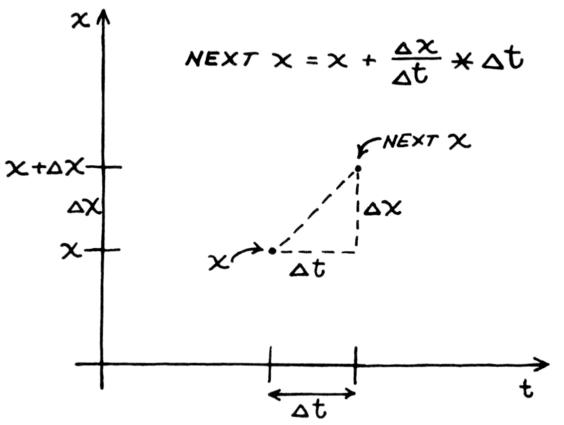

我可以称 NextX = x 加 dx/dt * dt。

I could call NextX = x plus dx/dt * dt.

是时候写软件了。

Time to write the software.

苹果手册解释了“for”和“next”循环。这是计算机如何“重复”解决问题的核心。

The Apple handbook explained a "for" and "next" loop. This is the heart of how a computer solves things "repeatedly."

我将创建一个索引，称之为 I，它是 t 时间的替代品。时间只是图表上的一个占位符、一个参考标记、一个散列标记。如果有更多就好了。

I'll create an index, call it I, that's a substitute for t, time. Time is just a place holder, a reference mark, a hash mark on a graph. If only there were more of it.

我会说“for I = 1 to 100”，就好像我想跟踪气球 100 个 1 秒的间隔。在每一秒开始时，我都会计算气球壳的速度。我将该速度乘以 1 秒，即可得出气球在那一秒内飞了多远。这将为我提供下一个职位。我现在可以尝到解决方案了。

I'll say "for I = 1 to 100," as if I want to track the balloon for 100 1-second intervals. At the beginning of each second, I'll calculate the speed of the shell of the balloon. I'll multiply that speed by 1 second to find how far the balloon goes in that second. That will give me the next position. I can taste the solution now.

最后一个问题。我如何告诉计算机我希望时间增量始终为 1。如果我在第二个数字 43，我如何知道乘以 1 而不是 43？一定有窍门。

One last problem. How do I tell the computer that I want the time increment always to be 1. If I'm at second number 43, how do I know to multiply by 1 and not 43? There's got to be a trick.

有一个技巧。在每个步骤中，定义最后一个步骤。例如，如果我处于第 43 步，则最后一步将为 42。步长大小始终为 1。在程序中，我将最后一步称为“最后！” （计算机术语中的“最后一个我”），程序将从最后一个开始！等于零。我将通过编程计算气球压力、膨胀速度以及气球的新尺寸 (x)

There is a trick. At each step, define a last step. For example, if I'm at step 43, the last step will be 42. The step size will always be one. In the program I'll call the last step "last!" (computerese for "last I"), and the program will start with last! equal to zero. I'll calculate the balloon pressure, the speed of expansion, and the new size of the balloon (x) by programming

[figure not shown]

然后我会让当前的 I (1) 等于最后一个 I，所以当我继续下一个 1 (2) 时，我会通过从当前 1 (2) 中减去最后一个 I (1) 得到 1 。Apple 的计划将是：

Then I'll make the present I (1) equal to the last I, so when I go on to the next 1 (2), I'll get 1 by subtracting the last I (1) from the present 1 (2). The program for the Apple will be:

[figure not shown]

就是这么简单。我怎么花了这么长时间才找到解决方案？

It's so simple. How did it take so long for me to arrive at the solution?

我向公共汽车的窗外望去。我在车上行驶了三英里，过了车站，车在沃特敦广场掉头。空间和时间都在思想中崩溃了。

I looked out the window of the bus. I'd stayed on it for three miles past my stop, and it was turning around at Watertown Square. Space and time had collapsed in thought.

8月25日

August 25

我向 Greene 展示了我的解决方案，他说：“没关系。如果你现在停下来，我会给你 B。不过，如果你想要 A，我会再给你一周的时间，你可以更改模型以适应气球的表皮有质量的情况。”

I showed my solution to Greene and he said, "That's fine. I'll give you a B if you stop now. If you want an A, though, I'll give you another week, and you can change the model to accommodate the case where the skin of the balloon has mass."

没问题。我对程序做了一点改动，四天后把解决方案留在了他的桌子上。

No problemo. I made a slight change to the program and left the solution on his desk four days later.

9 月 2 日

September 2

我在研究所周围穿着我的，或者更确切地说是唐的实验室夹克。这让我感觉自己是这个地方的一部分。新来者惊恐的面孔进一步增强了我的信心。我冲上楼梯，来到格林的办公室领取我的 A。

I wore my, or rather Don's, lab jacket around the institute. It made me feel a part of the place. The scared faces of the newcomers further fed my confidence. I bolted up the stairs to Greene's office to receive my A.

格林的秘书体重增加了三十磅，也许四十磅，她来回摆动秒表，防止自己跑到六号楼的机器前去买一包骆驼。

Greene's secretary had put on thirty, maybe forty pounds, and she bobbed a stopwatch on a string back and forth to prevent herself from running down to the machine in Building 6 to get a pack of Camels.

她拿出了我的文件。“你得了 B，”她说。

She pulled out my file. "You got a B," she said.

那条蛇。我做了额外的工作，但他还是给了我 B。如果他给我一个 A，那么 A 就会抵消我第一学期的平均绩点 (GPA) 中的一个 C。我不在乎他有多少高层联系人。我们达成了一项协议，但他却退出了。

That snake. I did the extra work and he gave me a B anyway. If he'd given me an A, the A would have canceled out one of the C's from the first term on my grade point average (GPA). I don't care how many high-level contacts he has. We made a deal and he was backing out of it.

“他现在在吗？” 我问。

"Is he in now?" I asked.

“是啊，你想见他吗？”

"Yes, would you like to see him?"

“是的。马上。”

"Yes. Right away."

我进去了。他戴着眼镜坐在办公桌前，阅读美国工程院的一次会议记录。他站起来向我打招呼。

I went in. He was sitting at his desk, glasses on, reading proceedings from a meeting of the National Academy of Engineering. He stood up to greet me.

“你为什么给我一个B？我以为我们已经达成协议了。”

"Why'd you give me a B? I thought we had an agreement."

我们都一动不动地站在他办公桌的两侧。

We both stood still, on opposite sides of his desk.

“是的，我们做到了，但最终，尽管你付出了很大的努力来解决问题的额外部分，你提交的文章，好吧，它只是没有达到我所能做到的完美程度。 “良心称其为‘A’工作。我可以让你看看我给出的一些学期项目的副本，我认为你会同意的。”

"Yes, we did, but in the end, even though you made a good effort at solving the additional piece of the problem, the write-up you submitted, well, it just didn't have the polish of what I could in good conscience call 'A' work. I could let you look at copies of some term projects I've given A's on, and I think you'd agree."

“但是你为什么不告诉我，给我一个机会做更多的工作来解决这个问题？”

"But why didn't you tell me, give me a chance to do more work, to fix it?"

“好吧，有时候你只需要关闭一个项目的账簿。你已经完成了很好的工作，只是不是 A 工作。我确信仅仅一个 B 不会让你的平均成绩下降那么多， “ 他说。他肯定以为我大部分都是A。他以一种令人费解的方式给了我一张信任票。

"Well, there comes a time when you just have to close the books on a project. You've done good work, just not A work. I'm sure just one B won't bring your grade point average down that much," he said. He must have thought I had mostly A's. In a convoluted way he'd just given me a vote of confidence.

“是的，好吧，这也没有多大帮助。也许你是对的。是时候减少我的损失并继续前进了。”

"Yeah, well, it won't help that much either. Maybe you're right. It's time to cut my losses and press on."

我已经过了试用期了

I'm off probation.

我属于这里。

I belong here.

# 章节

# C H A P T E R

# 11

# 11

# 西格玛德尔塔

# Sigma Delta

日程：

Schedule:

82 年秋季：2.70 设计概论（威尔逊）

Fall '82: 2.70 Introduction to Design (Wilson)

2.14 反馈控制系统（布鲁克斯）

2.14 Feedback Control Systems (Brooks)

2.996 论文

2.996 Thesis

9 月 3 日

September 3

“这是白胡椒吗？” 电话那头的声音说道。“我是从学生事务主任办公室打来的。高级宿舍刚刚出现了一名导师的空缺。您有兴趣面试一下舍监吗？”

"Is this Pepper White?" the voice at the other end of the phone said. "I'm calling from the Dean of Student Affairs' office. An opening for a tutor has just come up, at Senior House. Would you be interested in interviewing with the housemaster?"

“当然可以。我需要做什么？”

"Sure. What do I have to do?"

“给高级学院的多尔西教授打电话就可以了；他的电话号码在电话簿里。你可以和他预约。”

"Just call Professor Dorsey at Senior House; his number's in the directory. You can set up an appointment with him."

是的，宝贝。也许毕竟有机会担任导师职位。麻省理工学院的导师是州立学校所说的“RA”（Residence Assistant的缩写），而哈佛则称之为“House Fellow”，因为哈佛喜欢给人们起一个听起来很重要的名字。

Yeah baby. Maybe there's a chance for a tutor position after all. A tutor at MIT is what state schools call an R.A., short for resident assistant, and what Harvard calls a house fellow, because Harvard likes to give important sounding names to people.

在春天骑自行车的间隙，我申请了几个本科生宿舍的导师职位：麦格雷戈，那里的导师套房可以欣赏到波士顿价值数百万美元的景色；在麦考密克，原教旨主义家庭将女儿送到这里的全女性宿舍（“嘿，也许他们的男朋友需要咨询，”我对舍监说）；在贝克斯利，从 7 号楼穿过马萨诸塞大街的酸性岩石宿舍。有传言称，在贝克斯利，化学专业的学生合成了自己的迷幻药，而联邦调查局正渴望破获。在贝克斯利，我进入了第一轮导师淘汰赛。

In the springtime between bicycle rides I'd applied for tutor positions at several undergraduate dormitories: at MacGregor, where the tutor suites have million-dollar views of Boston; at McCormick, the all-women dorm where the fundamentalist families send their daughters ("Hey, maybe their boyfriends need counseling," I said to the housemaster); and at Bexley, the acid rock dorm across Mass. Ave. from Building 7. At Bexley, rumor had it, the chem majors synthesized their own LSD, and the FBI was just aching to make a bust. At Bexley, I made it to the first round of tutor elimination.

4 月 1 日

April 1

面试由坐在舍监雅各布·利维教授和夫人客厅周围的十二名导师候选人组成。如果其他十一位候选人像我一样想的话，如果其他十一位候选人在马萨诸塞大街人行横道上被一辆自卸卡车碾过，没有一个候选人会感到非常失望。一百名贝克斯利派中约有三十人提出了一般性问题。作为候选人，我们的工作就是顺利、熟练地在我们自己选择的适当时间回答问题。

The interview consisted of the twelve tutor candidates sitting around the living room of the housemasters, Professor and Mrs. Jacob Levy. None of the candidates, if they thought like me, would be very disappointed if the other eleven were run over by a dumptruck at the Mass Ave. crosswalk. About thirty of the one hundred Bexleyites asked general questions. Our job as candidates was smoothly, deftly, to answer a question at an appropriate time of our own choosing.

穿着齐柏林飞艇 T 恤的孩子提出了这样的问题：“那么，如果我经历了一次糟糕的迷幻之旅，如果你发现了我，你会怎么做？”

The kid wearing the Led Zeppelin T-shirt posed the question, "So, like, if I were on a bad acid trip, like, and if you found me, like, what would you do?"

这似乎是我发声的最佳时机。“好吧，你的事就是你的事；我的意思是，如果你想把你的天才大脑炸出来，那就去吧。我会叫救护车，把你送到医院，在那里他们可以照顾你，也许会把你的胃抽出来，并防止你伤害自己。至于我自己，我已经八年没有服用过阿司匹林了，而且我一直相当健康和快乐。”

It seemed as good a time as any for me to speak up. "Well, your business is your business; I mean if you want to fry your highly gifted brain out, go ahead. I'll call an ambulance and get you to a hospital where they can take care of you, maybe pump your stomach out, and keep you from hurting yourself. As for myself, I haven't taken so much as an aspirin for about eight years, and I've been fairly healthy and happy."

蜂鸣器声音。错误的答案。

Buzzer sound. Wrong answer.

坐在我旁边的生物化学专业的学生，留着长发、胡须和小胡子，离我的目标更近一些。

The biochem major sitting next to me, with longish hair, beard, and mustache, hit the mark a little closer.

“嗯，各种消遣性药剂我都试过了，还有一本笔记本，里面全是配方，或许对你们有用，呵呵。至于迷幻药那场戏，我倒是愿意。”就像我曾经对我的一个朋友那样说服你。我会说，‘没关系，你来到跑道上，你不会摔倒和流浪的，伙计，放轻松点坚持下去，很好，很顺利，我们会把你弄下来，就这样，我们走吧，没关系。” 我会说类似的话，直到你放下为止。”

"Well, I've done about every kind of recreational pharmaceutical there is, and I've got a notebook full of recipes, which might come in handy for you guys, heh heh. As far as the acid trip scene, I'd like talk you down like I once did for a friend of mine. I'd say something like, 'It's OK, you're coming to the runway, you're not going to crash and bum, man, just go easy with the stick, nice and smooth, we'll get you down, that's it here we go it's all right.' I'd say something like that until you came down off it."

蜂鸣器声音。正确答案。

Buzzer sound. Right answer.

9月3日又来了

September 3 again

我和多尔西教授的约会是在七点，我沿着风景优美的路线从马萨诸塞州查尔斯大道前往高级学院。傍晚阳光下的帆船和背景中波士顿天际线的真实世界让我回想起那一年以前，当我还是一个科技婴儿时。我已经好起来了；我就知道。现在，如果我能说服自己成为一名家庭教师，我就能还清债务了。

My appointment with Professor Dorsey was at seven and I took the scenic route to Senior House-down the Charles from Mass. Ave. The sailboats in the late evening sun and the real world of Boston's skyline in the background made me think back to the year before, when I was a technological infant. I'd gotten better; I knew it. Now if I could just talk my way into being a tutor I'd be able to pay my debts.

空气中有一丝寒意，这让我想起了布鲁塞尔的秋天，还有斯蒂芬妮。自十二月以来我就没有再打电话或写信，她也没有。布鲁日桥下的水。我想知道她是否已经找到了别人。

There was a little chill in the air, and it made me remember the fall in Brussels, and Stephanie. I hadn't called or written since December, and neither had she. Water under the bridge in Bruges. I wondered whether she'd found someone else.

老宅的基石上刻着“1917”字样。1917 年，我母亲的父亲穿过佛兰德斯前往巴黎。穿过 L 形宿舍和格雷总统后院围墙包围的庭院的玻璃入口，吉米·亨德里克斯用四楼窗户外的扬声器大声播放着《紫雾》。

Into Senior House's cornerstone was chiseled "1917." In 1917 my mother's father marched across Flanders to Paris. Past the glass entryway to the courtyard enveloped by the L-shaped dormitory and the wall of President Gray's backyard, Jimi Hendrix played "Purple Haze" loudly on speakers pointed out of a fourth-floor window.

格雷总统花园里的树荫让迅速降临的黄昏变得更加黑暗，而前方庭院里高大的树下的篝火的光芒则让暮色变得更加明亮。一个留着长发、长满青春痘、身穿黑色T恤、7号楼火焰图案下写着“访问地狱”的孩子朝艾姆斯街走去。我打了个招呼。

The fast-falling dusk was made darker from the shade of the trees in President Gray's garden, lighter by the light of the bonfire ahead in the courtyard under the tall tree. A kid with long hair and lots of zits and a black T-shirt with "Visit Hell" written underneath a flaming design of Building 7 walked past toward Ames Street. I said hello.

他没有回应，没有点头，没有发出声音，也没有承认我的存在。

He returned no response, no nod, no noise, no acknowledgment of my existence.

两个挽着手走的女人也无视我的问候。

Two women walking arm in arm also ignored my greeting.

一个高个子男人扎着马尾辫，戴着耳环，穿着一些印度男人穿的衣服，但我们美国人称之为裙子，他打了招呼。我没有打招呼。

A tall guy wearing a ponytail, an earring, and a garment that is wom by some Indian men but we in America call a skirt said hello. I didn't say hello.

在四楼窗户附近，扬声器播放着亨德里克斯的音乐，阳台上挂着玛丽的“运动死亡”T 恤的放大版。骷髅头，星条旗，骷髅牙上的“只有生命才能杀死你”，在篝火的微风中轻轻摇曳。我想，这个地方比贝克斯利还要糟糕。

Near the fourth-floor window, where the speakers played Hendrix, the larger-than-life version of Mary's "Sport Death" T-shirt hung from the balcony. The skull, the stars and stripes, the "Only life can kill you" in the skull's teeth, waved gently in the bonfire's breeze. This place is even worse than Bexley, I thought.

另一个扎着马尾辫的家伙在轮胎秋千上绕着树旋转。他的背部从轮胎处水平向外拱起，离心力将他的马尾辫向外推，他与篝火只有一根头发丝的宽度，他的头从未靠近树；他是一个带有板载微处理器的绳球。他可能已经在电脑上计算出了自己的轨迹，并且准确地知道自己的误差幅度是多少。

Another guy with a ponytail spun around the tree from the tire swing. He arched his back horizontally outward from the tire, and the centrifugal force thrust his ponytail outward as he missed the bonfire by a hair's breadth and his head never came near the tree; he was a tetherball with an on-board microprocessor. He'd probably calculated his trajectory on his computer and knew precisely what his margin for error was.

“是啊，运动死亡！” 一位篝火旁观者说道。体育是一种反抗、嘲讽的命令。那个旁观者穿着一件黄色 T 恤，上面写着“敢于友善”，我向他询问了去多尔西公寓的路线。

"Yeah, Sport Death!" one of the bonfire bystanders said. Sport was a command-to defy, to taunt. The bystander wore a yellow T-shirt that said, "Dare to be friendly," and I asked him for directions to the Dorseys' apartment.

“当然，就在手工艺品店二楼左边河边的地方，”他用愉快的语气说道。

"Sure, it's right down there on the left toward the river, on the second floor of Crafts," he said with a happy tone to his voice.

我与多尔西教授坐下来，他解释了情况。“嗯，你看，阿特金森的导师去澳大利亚内陆地区进行一些基因工程研究，以完成他在怀特黑德研究所的论文工作，他在那里感染了一些奇怪的疾病，正在悉尼的一家医院接受观察。”

I sat down with Professor Dorsey and he explained the situation. "Well, you see, the Atkinson tutor was off doing some genetic engineering research in the Australian outback for his thesis work at the Whitehead institute, and he contracted some strange disease out there and is under observation in a hospital in Sydney."

“哎呀，太可怕了，我希望他能康复。” 但不会很快成为现实。

"Gee, that's terrible; I hope he recovers." But not real soon.

多尔西教授继续说道：“新生高峰周即将到来，除了少数学生之外，学生还没有回来。通常情况下，这是一个非常疯狂的时期，为了防止整个地方爆炸，我认为我们真的需要我们的导师阵容齐全。”

Professor Dorsey continued, "Freshman rush week is coming right up, and the students aren't back yet except for a few. Typically, it's a pretty wild time, and to keep the whole place from blowing up, I think we really need our full complement of tutors."

“我以为都是高年级学生，这不就是他们叫高级楼的原因吗？” 我问。

"I thought it was all seniors; isn't that why they call it Senior House?" I asked.

"No, it's the senior house, the oldest dorm in the institute. There are all classes here, and also some graduate students. Part of the issue for rush week is that this place is usually the freshmen's last choice-it's generally a tie between here and Bexley. Nobody wants to live here; they'd rather live at the more middle-of-the road dorms like Macgregor and New House up the river, or at the frats; there's even been talk about shutting down Senior House as a dorm. So we'd really like to have as many tutors on hand as possible, just to keep an eye on things and to be a friendly face for the lost freshmen."